# Meta-Analyzing ICC Estimates Graphs

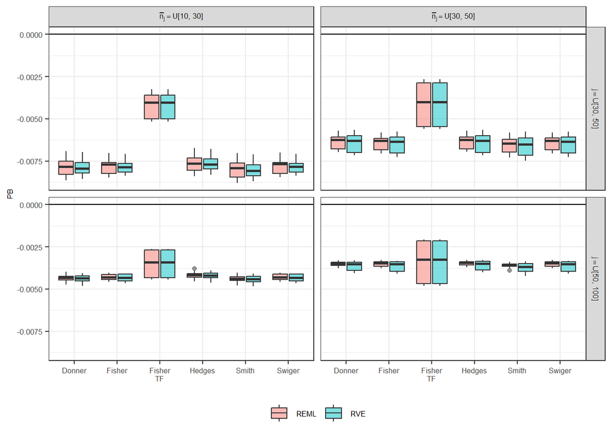

```r
perf_crit |>filter(var_combo_graph == 0.05) |>
  ggplot(aes(x = variance, y = bias_icc, fill = model)) +
  geom_hline(yintercept = 0, linetype = "solid") +
  geom_boxplot(alpha = .5) +
  facet_grid(nj_size ~ n_bar_size,
             labeller = label_bquote(rows = j ==.(nj_size),
                                            cols = bar(n)[j]==.(n_bar_size))) +
  labs(x = NULL, y = "PB", fill = NULL) +
  theme_bw() +
  theme(legend.position = "bottom",
        axis.text.x = element_text(size = 6.5),
        axis.text.y = element_text(size = 6.5),
        plot.caption=element_text(hjust = 0, size = 6),
       # legend.title=element_text(size = 6),
        legend.text=element_text(size = 6.5),
        axis.title.x = element_text(size=6.5),
        axis.title.y = element_text(size=6.5),
       # strip.background =element_rect(fill="white")
        strip.text.x = element_text(size = 6.5, face="bold"),
        strip.text.y = element_text(size = 6.5, face="bold")
      )
```

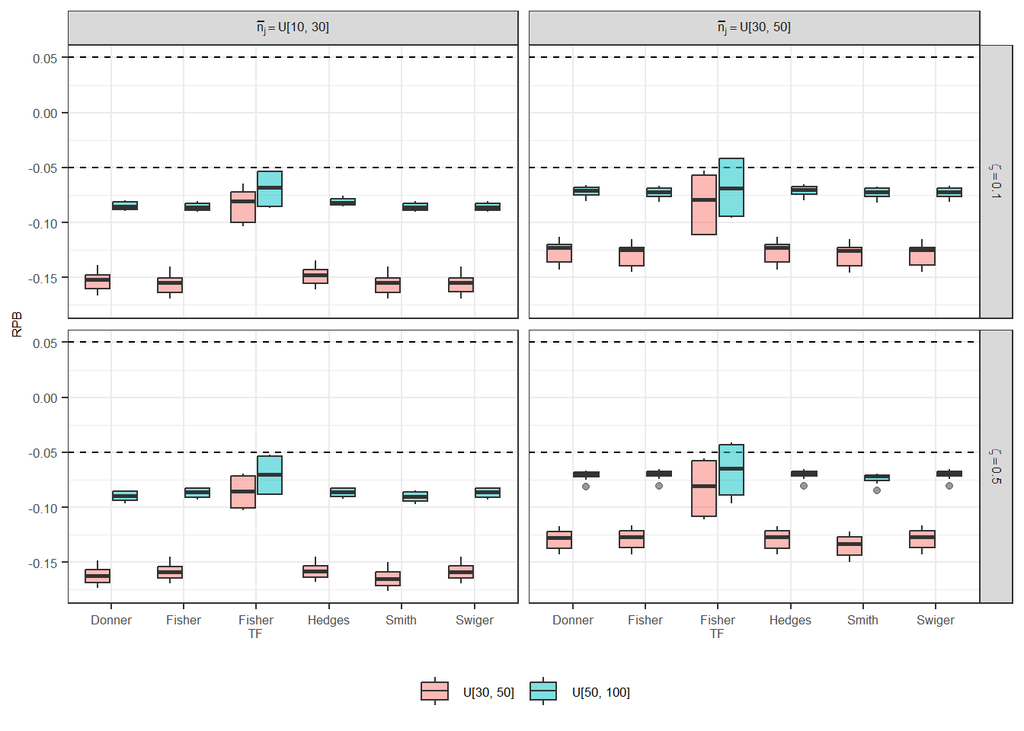

```r
perf_crit |>filter(var_combo_graph == 0.05) |>
  ggplot(aes(x = variance, y = rel_bias_icc, fill = nj_size)) +
  geom_hline(yintercept = .05, linetype = "dashed") +
  geom_hline(yintercept = -.05, linetype = "dashed") +
  geom_boxplot(alpha = .5) +
  facet_grid(n_bar_prop ~ n_bar_size,
             labeller = label_bquote(rows = zeta ==.(n_bar_prop),
                                            cols = bar(n)[j]==.(n_bar_size))) +
  labs(x = NULL, y = "RPB", fill = NULL) +
  theme_bw() +
  theme(legend.position = "bottom",
        axis.text.x = element_text(size = 6.5),
        axis.text.y = element_text(size = 6.5),
        plot.caption=element_text(hjust = 0, size = 6),
       # legend.title=element_text(size = 6),
        legend.text=element_text(size = 6.5),
        axis.title.x = element_text(size=6.5),
        axis.title.y = element_text(size=6.5),
       # strip.background =element_rect(fill="white")
        strip.text.x = element_text(size = 6.5, face="bold"),
        strip.text.y = element_text(size = 6.5, face="bold")
      )
```

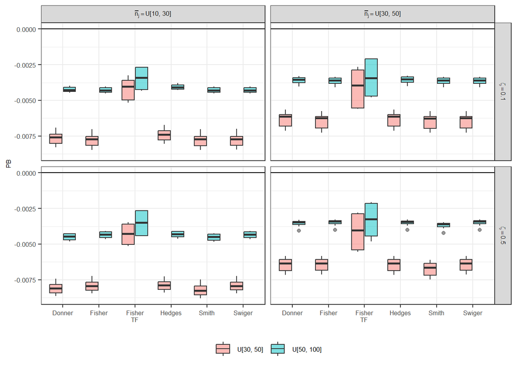

```r
perf_crit |>filter(var_combo_graph == 0.05) |>
  ggplot(aes(x = variance, y = bias_icc, fill = nj_size)) +
  geom_hline(yintercept = 0, linetype = "solid") +
  geom_boxplot(alpha = .5) +
  facet_grid(n_bar_prop ~ n_bar_size,
             labeller = label_bquote(rows = zeta ==.(n_bar_prop),
                                            cols = bar(n)[j]==.(n_bar_size))) +
  labs(x = NULL, y = "PB", fill = NULL) +
  theme_bw() +
  theme(legend.position = "bottom",
        axis.text.x = element_text(size = 6.5),
        axis.text.y = element_text(size = 6.5),
        plot.caption=element_text(hjust = 0, size = 6),
       # legend.title=element_text(size = 6),
        legend.text=element_text(size = 6.5),
        axis.title.x = element_text(size=6.5),
        axis.title.y = element_text(size=6.5),
       # strip.background =element_rect(fill="white")
        strip.text.x = element_text(size = 6.5, face="bold"),
        strip.text.y = element_text(size = 6.5, face="bold")
      )
```

# 4 SE of ICC

## 4.1 Interactions

### 4.1.1 True ICC vs num pooled ICCs

Figure 12

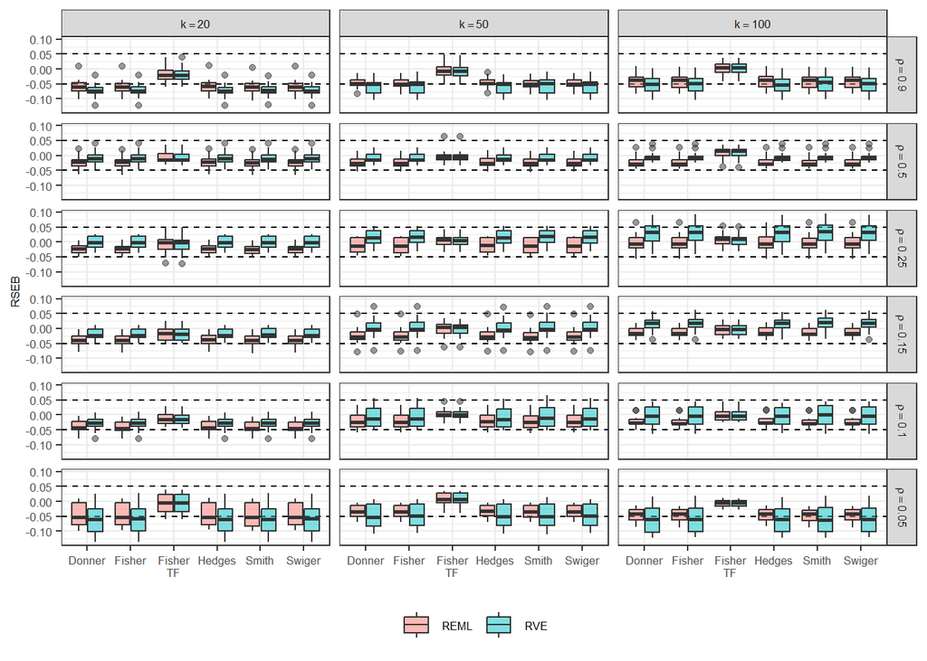

```r
perf_crit |>ggplot(aes(x = variance, y = rel_bias_se_ICC, fill = model)) +
  geom_hline(yintercept = .05, linetype = "dashed") +
  geom_hline(yintercept = -.05, linetype = "dashed") +
  geom_boxplot(alpha = .5) +
  facet_grid(var_combo_graph_f ~ icc_est_n,
             labeller = label_bquote(rows = rho ==.(as.character(var_combo_graph_f)),
                                     cols = k ==.(icc_est_n))) +
  labs(x = NULL, y = "RSEB", fill = NULL) +
  theme_bw() +
  theme(legend.position = "bottom",
        axis.text.x = element_text(size = 6.5),
        axis.text.y = element_text(size = 6.5),
        plot.caption=element_text(hjust = 0, size = 6),
       # legend.title=element_text(size = 6),
        legend.text=element_text(size = 6.5),
        axis.title.x = element_text(size=6.5),
        axis.title.y = element_text(size=6.5),
       # strip.background =element_rect(fill="white")
        strip.text.x = element_text(size = 6.5, face="bold"),
        strip.text.y = element_text(size = 6.5, face="bold")
      )
```

```r
ggsave("RSEB_numICC.png", width = 6.8, height = 5, units = "in")
```

```r
# perf_crit |>ggplot(aes(x = variance, y = rel_bias_se_ICC, fill = model)) +
#   geom_hline(yintercept = .05, linetype = "dashed") +
#   geom_hline(yintercept = -.05, linetype = "dashed") +
#   geom_boxplot(alpha = .5) +
#   facet_grid( var_combo_graph_f ~ icc_est_n,
#              labeller = label_bquote(rows = rho ==.(as.character(var_combo_graph_f)),
#                                             cols = k ==.(icc_est_n))
#              ) +
#   labs(x = NULL, y = "RSEB", fill = NULL) +
#   theme_bw() +
#   theme(
#     legend.position = "bottom",
#         axis.text.x = element_text(size = 6.5),
#         axis.text.y = element_text(size = 6.5),
#
#         plot.caption=element_text(hjust = 0, size = 6),
#        # legend.title=element_text(size = 6),
#         legend.text=element_text(size = 6.5),
#         axis.title.x = element_text(size=6.5),
#         axis.title.y = element_text(size=6.5),
#       #  strip.background =element_rect(fill="white")
#         strip.text.x = element_text(size = 6.5, face="bold"),
#         strip.text.y = element_text(size = 6.5, face="bold")
#       )

#ggsave("RPB_se_numICC.png", width = 6.8, height = 5, units = "in")
```

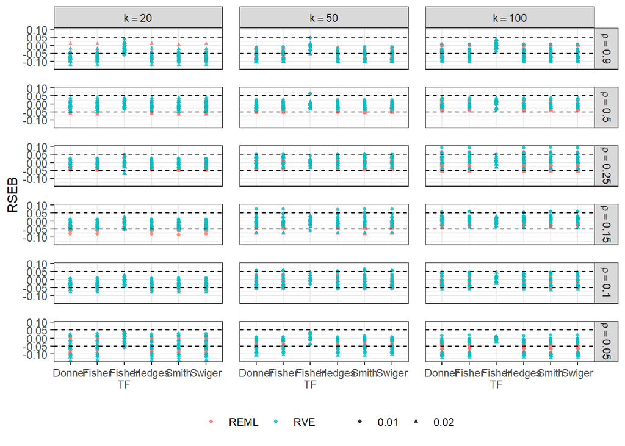

```r
perf_crit |>
  ggplot(aes(x = as.character(variance), y = rel_bias_se_ICC,
             color = model,
             shape = as.character(tau)
             )
         ) +
  geom_point(alpha = .8,
           #  position = position_jitter(height = .3),
             size = 1)  +
  geom_hline(yintercept = .05, linetype = "dashed") +
  geom_hline(yintercept = -.05, linetype = "dashed") +
  facet_grid( var_combo_graph_f ~ icc_est_n,
             labeller = label_bquote(rows = rho ==.(as.character(var_combo_graph_f)),
                                            cols = k ==.(icc_est_n))) +
  labs(
    x = NULL,
    y ="RSEB",
    color = "", shape = ""
  ) +
  theme_bw() +
  theme(
    plot.caption=element_text(hjust = 0, size = 10),
    legend.position= "bottom",
    panel.spacing.x = unit(5, "mm"),
    panel.spacing.y = unit(5, "mm"),
  )
```

```r
ggsave("RSEB_numICC_alt2.png", width = 6.8, height = 5, units = "in")
```

### 4.1.2 True ICC vs tau (between study )

Figure 13

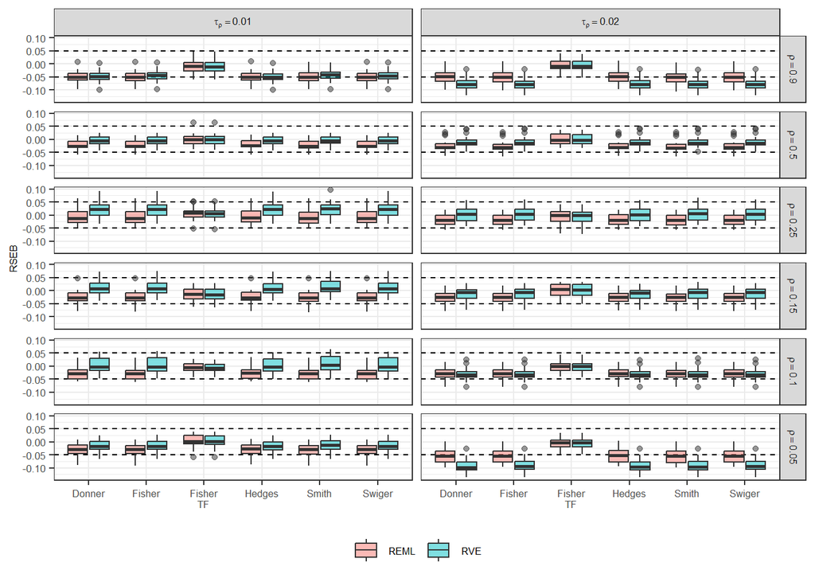

```r
perf_crit |>ggplot(aes(x = variance, y = rel_bias_se_ICC, fill = model)) +
  geom_hline(yintercept = .05, linetype = "dashed") +
  geom_hline(yintercept = -.05, linetype = "dashed") +
  geom_boxplot(alpha = .5) +
  facet_grid( var_combo_graph_f ~ tau,
             labeller = label_bquote(rows = rho ==.(as.character(var_combo_graph_f)),
                                            cols = tau[rho]==.(tau))) +
  labs(x = NULL, y = "RSEB", fill = NULL) +
  theme_bw() +
  theme(
    legend.position = "bottom",
        axis.text.x = element_text(size = 6.5),
        axis.text.y = element_text(size = 6.5),

        plot.caption=element_text(hjust = 0, size = 6),
       # legend.title=element_text(size = 6),
        legend.text=element_text(size = 6.5),
        axis.title.x = element_text(size=6.5),
        axis.title.y = element_text(size=6.5),
      #  strip.background =element_rect(fill="white")
        strip.text.x = element_text(size = 6.5, face="bold"),
        strip.text.y = element_text(size = 6.5, face="bold")
      )
```

```r
ggsave("RSEB_tau.png", width = 6.8, height = 5, units = "in")
```

### 4.1.3 True ICC vs number of clusters

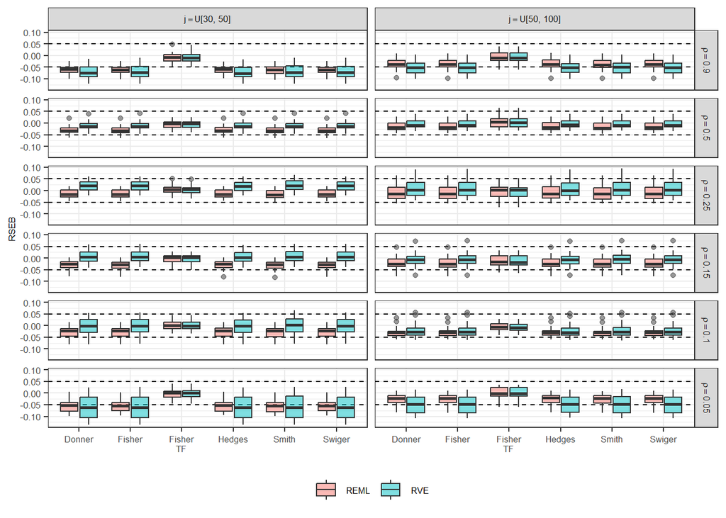

```r
perf_crit |>ggplot(aes(x = variance, y = rel_bias_se_ICC, fill = model)) +
  geom_hline(yintercept = .05, linetype = "dashed") +
  geom_hline(yintercept = -.05, linetype = "dashed") +
  geom_boxplot(alpha = .5) +
  facet_grid( var_combo_graph_f ~ nj_size,
             labeller = label_bquote(rows = rho ==.(as.character(var_combo_graph_f)),
                                            cols = j== .(nj_size))) +
  labs(x = NULL, y = "RSEB", fill = NULL) +
  theme_bw() +
  theme(
    legend.position = "bottom",
        axis.text.x = element_text(size = 6.5),
        axis.text.y = element_text(size = 6.5),

        plot.caption=element_text(hjust = 0, size = 6),
       # legend.title=element_text(size = 6),
        legend.text=element_text(size = 6.5),
        axis.title.x = element_text(size=6.5),
        axis.title.y = element_text(size=6.5),
      #  strip.background =element_rect(fill="white")
        strip.text.x = element_text(size = 6.5, face="bold"),
        strip.text.y = element_text(size = 6.5, face="bold")
      )
```

```r
#ggsave("RPB_se_j.png", width = 6.8, height = 5, units = "in")
```

### 4.1.4 True ICC vs cluster size

Figure 14

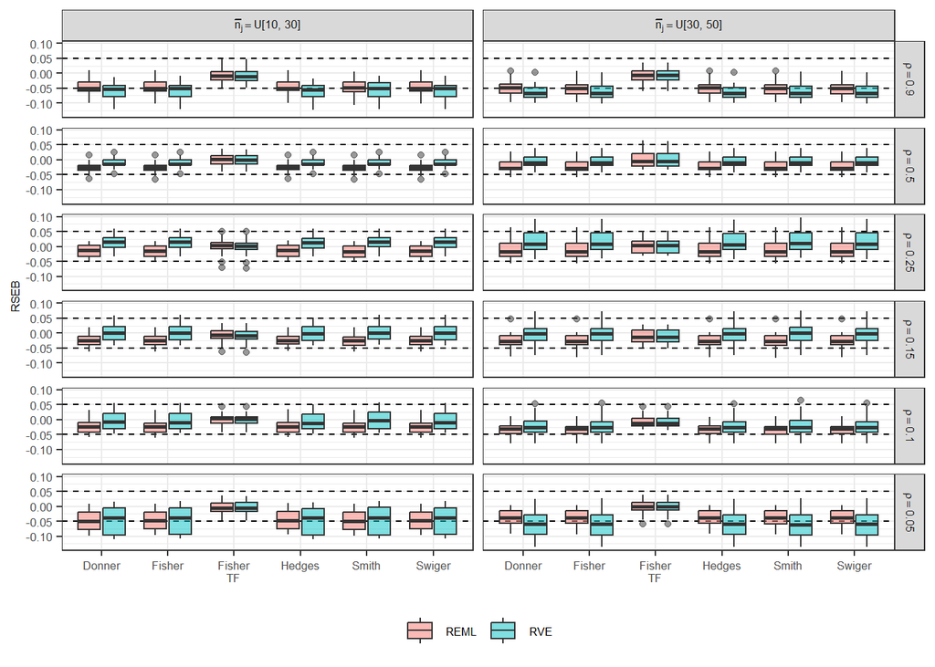

```r
perf_crit |>ggplot(aes(x = variance, y = rel_bias_se_ICC, fill = model)) +
  geom_hline(yintercept = .05, linetype = "dashed") +
  geom_hline(yintercept = -.05, linetype = "dashed") +
  geom_boxplot(alpha = .5) +
  facet_grid( var_combo_graph_f ~ n_bar_size,
             labeller = label_bquote(rows = rho ==.(as.character(var_combo_graph_f)),
                                            cols = bar(n)[j]==.(n_bar_size))) +
  labs(x = NULL, y = "RSEB", fill = NULL) +
  theme_bw() +
  theme(
    legend.position = "bottom",
        axis.text.x = element_text(size = 6.5),
        axis.text.y = element_text(size = 6.5),

        plot.caption=element_text(hjust = 0, size = 6),
       # legend.title=element_text(size = 6),
        legend.text=element_text(size = 6.5),
        axis.title.x = element_text(size=6.5),
        axis.title.y = element_text(size=6.5),
      #  strip.background =element_rect(fill="white")
        strip.text.x = element_text(size = 6.5, face="bold"),
        strip.text.y = element_text(size = 6.5, face="bold")
      )
```

```r
ggsave("RSEB_nj.png", width = 6.8, height = 5, units = "in")
```

### 4.1.5 True ICC vs Degree of unbalance

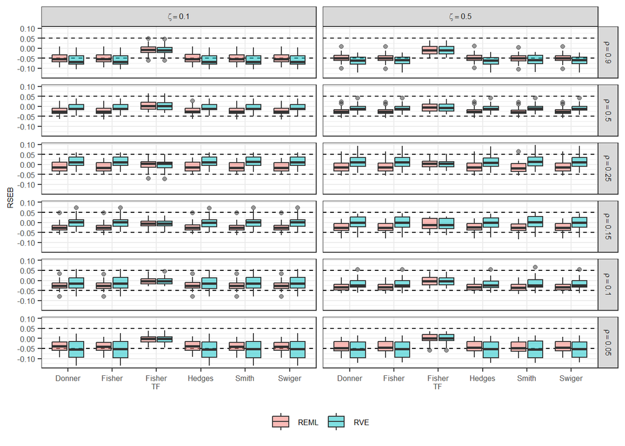

```r
perf_crit |>
  ggplot(aes(x = variance, y = rel_bias_se_ICC, fill = model)) +
  geom_hline(yintercept = .05, linetype = "dashed") +
  geom_hline(yintercept = -.05, linetype = "dashed") +
  geom_boxplot(alpha = .5) +
  facet_grid( var_combo_graph_f ~ n_bar_prop,
             labeller = label_bquote(rows = rho ==.(as.character(var_combo_graph_f)),
                                            cols = zeta ==.(n_bar_prop))) +
  labs(x = NULL, y = "RSEB", fill = NULL) +
  theme_bw() +
  theme(
    legend.position = "bottom",
        axis.text.x = element_text(size = 6.5),
        axis.text.y = element_text(size = 6.5),

        plot.caption=element_text(hjust = 0, size = 6),
       # legend.title=element_text(size = 6),
        legend.text=element_text(size = 6.5),
        axis.title.x = element_text(size=6.5),
        axis.title.y = element_text(size=6.5),
      #  strip.background =element_rect(fill="white")
        strip.text.x = element_text(size = 6.5, face="bold"),
        strip.text.y = element_text(size = 6.5, face="bold")
      )
```

```r
#ggsave("RSEB_n_bar_prop.png", width = 6.8, height = 5, units = "in")
```

### 4.1.6 number clusters vs cluster size

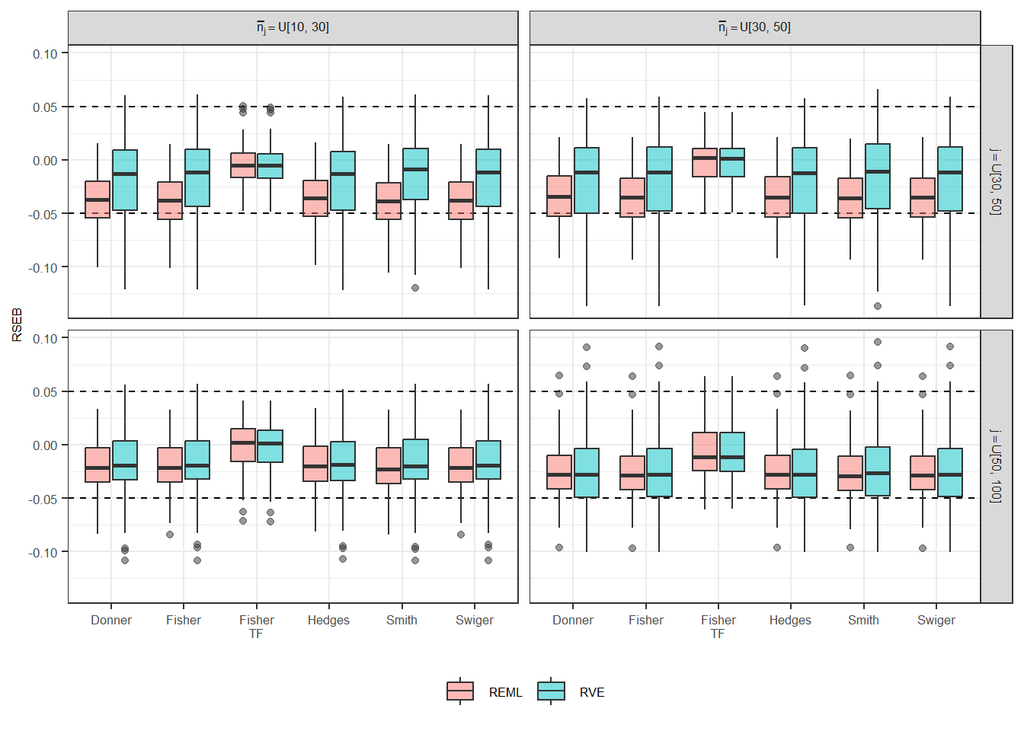

```r
perf_crit |>ggplot(aes(x = variance, y = rel_bias_se_ICC, fill = model)) +
  geom_hline(yintercept = .05, linetype = "dashed") +
  geom_hline(yintercept = -.05, linetype = "dashed") +
  geom_boxplot(alpha = .5) +
  facet_grid( nj_size ~ n_bar_size,
             labeller = label_bquote(rows = j ==.(nj_size),
                                            cols = bar(n)[j]==.(n_bar_size))) +
  labs(x = NULL, y = "RSEB", fill = NULL) +
  theme_bw() +
  theme(
    legend.position = "bottom",
        axis.text.x = element_text(size = 6.5),
        axis.text.y = element_text(size = 6.5),

        plot.caption=element_text(hjust = 0, size = 6),
       # legend.title=element_text(size = 6),
        legend.text=element_text(size = 6.5),
        axis.title.x = element_text(size=6.5),
        axis.title.y = element_text(size=6.5),
      #  strip.background =element_rect(fill="white")
        strip.text.x = element_text(size = 6.5, face="bold"),
        strip.text.y = element_text(size = 6.5, face="bold")
      )
```

```r
#ggsave("RSEB_j_nj.png", width = 6.8, height = 5, units = "in")
```

# 5 L2 Variance

## 5.1 Main Effects

### 5.1.1 L2 variance

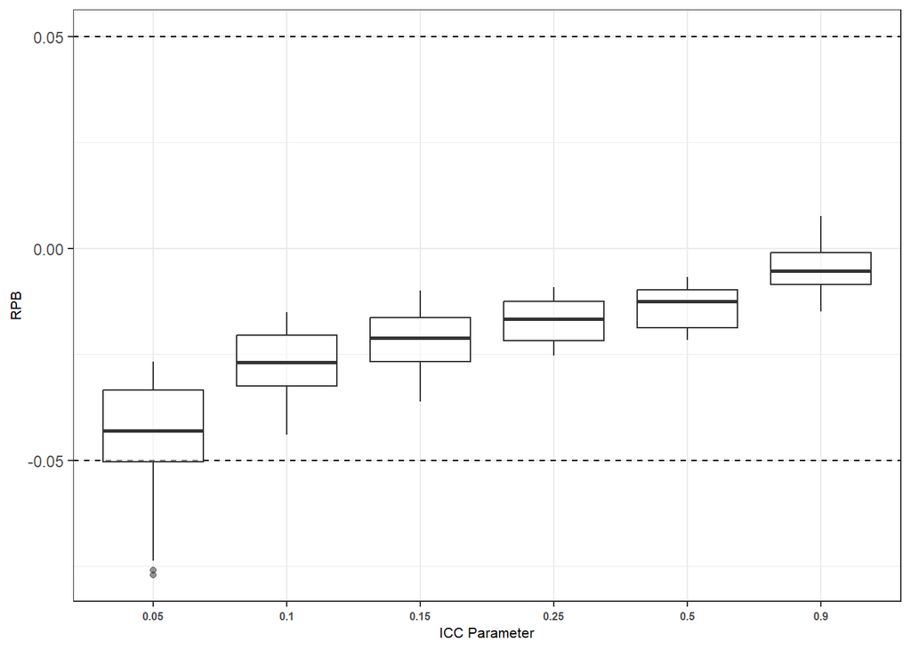

```r
perf_crit2  |> ggplot(aes(x = factor(var_combo_graph), y = rel_bias_clus)) +
  geom_hline(yintercept = .05, linetype = "dashed") +
  geom_hline(yintercept = -.05, linetype = "dashed") +
  geom_boxplot(alpha = .5) +
 # facet_grid( rows = vars(var_combo_graph_f)
              #labeller = label_parsed
#              ) +
  labs(x = "ICC Parameter", y = "RPB") +
  theme_bw() +
  theme(legend.position = "none",
        axis.text.x = element_text(size = 6, face="bold"),
        plot.caption=element_text(hjust = 0, size = 8),
        legend.title=element_text(size = 8),
        legend.text=element_text(size = 8),
        axis.title.x = element_text(size=8),
        axis.title.y = element_text(size=8),
        strip.background =element_rect(fill="white"))
```

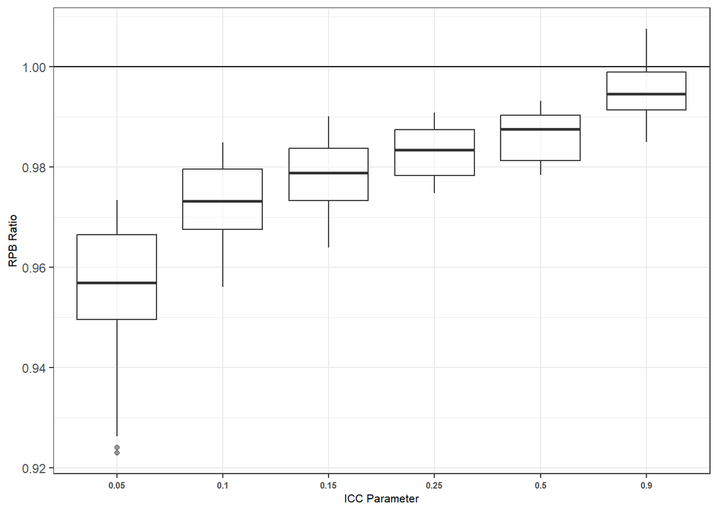

```r
perf_crit2  |> ggplot(aes(x = factor(var_combo_graph), y = rel_bias_clus_ratio)) +
  geom_hline(yintercept = 1, linetype = "solid") +
  geom_boxplot(alpha = .5) +
 # facet_grid( rows = vars(var_combo_graph_f)
              #labeller = label_parsed
#              ) +
  labs(x = "ICC Parameter", y = "RPB Ratio") +
  theme_bw() +
  theme(legend.position = "none",
        axis.text.x = element_text(size = 6, face="bold"),
        plot.caption=element_text(hjust = 0, size = 8),
        legend.title=element_text(size = 8),
        legend.text=element_text(size = 8),
        axis.title.x = element_text(size=8),
        axis.title.y = element_text(size=8),
        strip.background =element_rect(fill="white"))
```

## 5.2 Interactions

### 5.2.1 L2 variance by tau

Figure 15

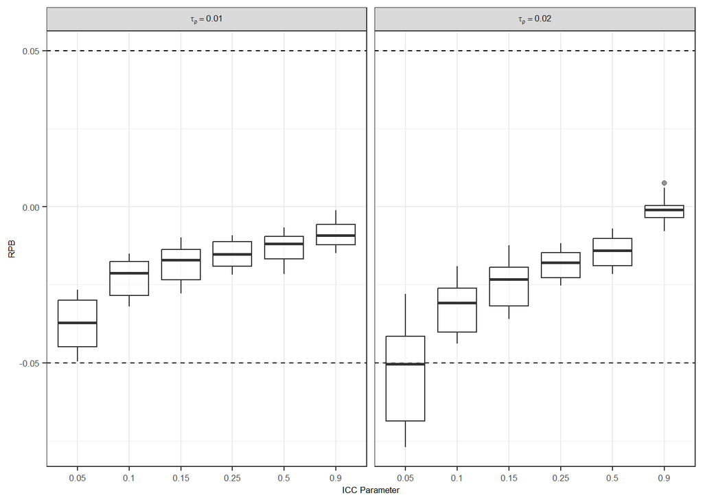

```r
perf_crit2  |> ggplot(aes(x = factor(var_combo_graph), y = rel_bias_clus)) +
  geom_hline(yintercept = .05, linetype = "dashed") +
  geom_hline(yintercept = -.05, linetype = "dashed") +
  geom_boxplot(alpha = .5) +
  facet_grid(cols = vars(tau)
             ,
             labeller = label_bquote(cols = tau[rho] ==.(tau))) +
  labs(x = "ICC Parameter", y = "RPB") +
  theme_bw() +
  theme(legend.position = "none",
        axis.text.x = element_text(size = 6.5),
        axis.text.y = element_text(size = 6.5),
      #  plot.caption=element_text(hjust = 0, size = 8),
      #  legend.title=element_text(size = 8),
      #  legend.text=element_text(size = 8),
        axis.title.x = element_text(size=6.5),
        axis.title.y = element_text(size=6.5),
       strip.text.x = element_text(size = 6.5, face="bold"),
        strip.text.y = element_text(size = 6.5, face="bold")
      )
```

```r
ggsave("RPB_L2_tau_mean.png", width = 6.8, height = 5, units = "in")
```

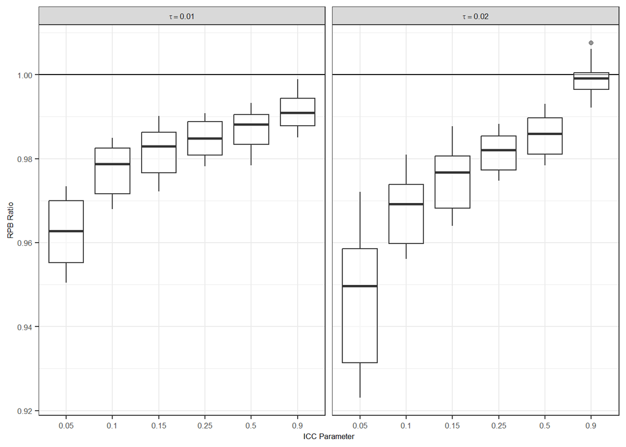

```r
perf_crit2  |> ggplot(aes(x = factor(var_combo_graph), y = rel_bias_clus_ratio)) +
  geom_hline(yintercept = 1, linetype = "solid") +
  geom_boxplot(alpha = .5) +
  facet_grid(cols = vars(tau )
             ,
             labeller = label_bquote(cols = tau ==.(tau))) +
  labs(x = "ICC Parameter", y = "RPB Ratio") +
  theme_bw() +
  theme(legend.position = "none",
        axis.text.x = element_text(size = 6.5),
        axis.text.y = element_text(size = 6.5),
      #  plot.caption=element_text(hjust = 0, size = 8),
      #  legend.title=element_text(size = 8),
      #  legend.text=element_text(size = 8),
        axis.title.x = element_text(size=6.5),
        axis.title.y = element_text(size=6.5),
       strip.text.x = element_text(size = 6.5, face="bold"),
        strip.text.y = element_text(size = 6.5, face="bold")
      )
```

### 5.2.2 L2 variance by number of clusters

Figure 16

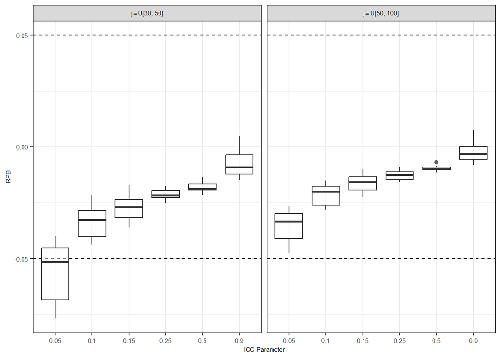

```r
perf_crit2  |> ggplot(aes(x = factor(var_combo_graph), y = rel_bias_clus)) +
  geom_hline(yintercept = .05, linetype = "dashed") +
  geom_hline(yintercept = -.05, linetype = "dashed") +
#  geom_hline(yintercept = 0, linetype = "solid", colour = "red") +
  geom_boxplot(alpha = .5) +
  facet_grid(cols = vars(nj_size )
             ,
             labeller = label_bquote(cols = j ==.(nj_size))) +
  labs(x = "ICC Parameter", y = "RPB") +
  theme_bw() +
  theme(legend.position = "none",
        axis.text.x = element_text(size = 6.5),
        axis.text.y = element_text(size = 6.5),
      #  plot.caption=element_text(hjust = 0, size = 8),
      #  legend.title=element_text(size = 8),
      #  legend.text=element_text(size = 8),
        axis.title.x = element_text(size=6.5),
        axis.title.y = element_text(size=6.5),
       strip.text.x = element_text(size = 6.5, face="bold"),
        strip.text.y = element_text(size = 6.5, face="bold")
      )
```

```r
ggsave("RPB_L2_j_mean.png", width = 6.8, height = 5, units = "in")
```

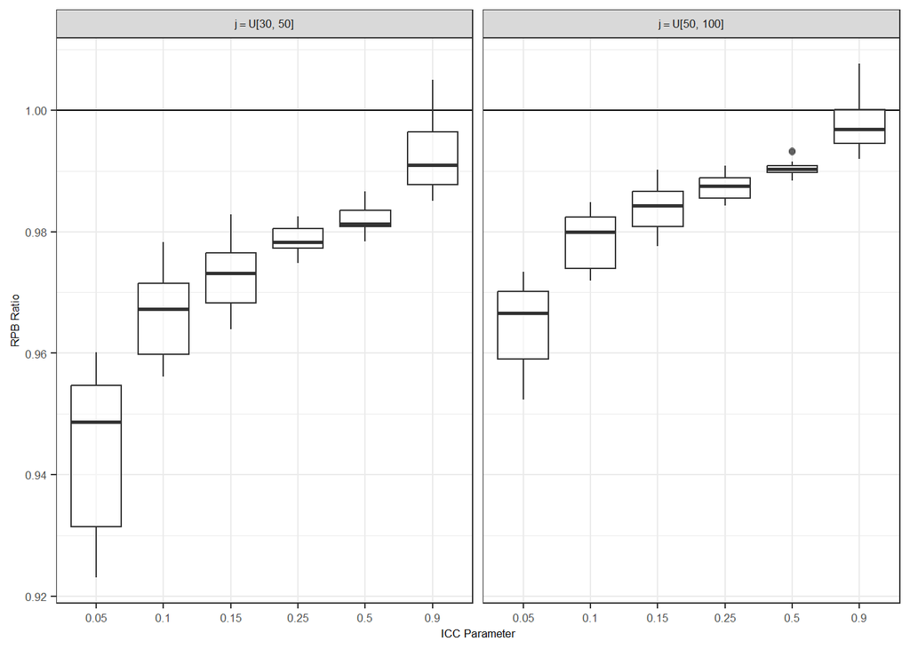

```r
perf_crit2  |> ggplot(aes(x = factor(var_combo_graph), y = rel_bias_clus_ratio)) +
  geom_hline(yintercept = 1, linetype = "solid") +

  geom_boxplot(alpha = .5) +
  facet_grid(cols = vars(nj_size )
             ,
             labeller = label_bquote(cols = j ==.(nj_size))) +
  labs(x = "ICC Parameter", y = "RPB Ratio") +
  theme_bw() +
  theme(legend.position = "none",
        axis.text.x = element_text(size = 6.5),
        axis.text.y = element_text(size = 6.5),
      #  plot.caption=element_text(hjust = 0, size = 8),
      #  legend.title=element_text(size = 8),
      #  legend.text=element_text(size = 8),
        axis.title.x = element_text(size=6.5),
        axis.title.y = element_text(size=6.5),
       strip.text.x = element_text(size = 6.5, face="bold"),
        strip.text.y = element_text(size = 6.5, face="bold")
      )
```

### 5.2.3 L1 variance by clustersize

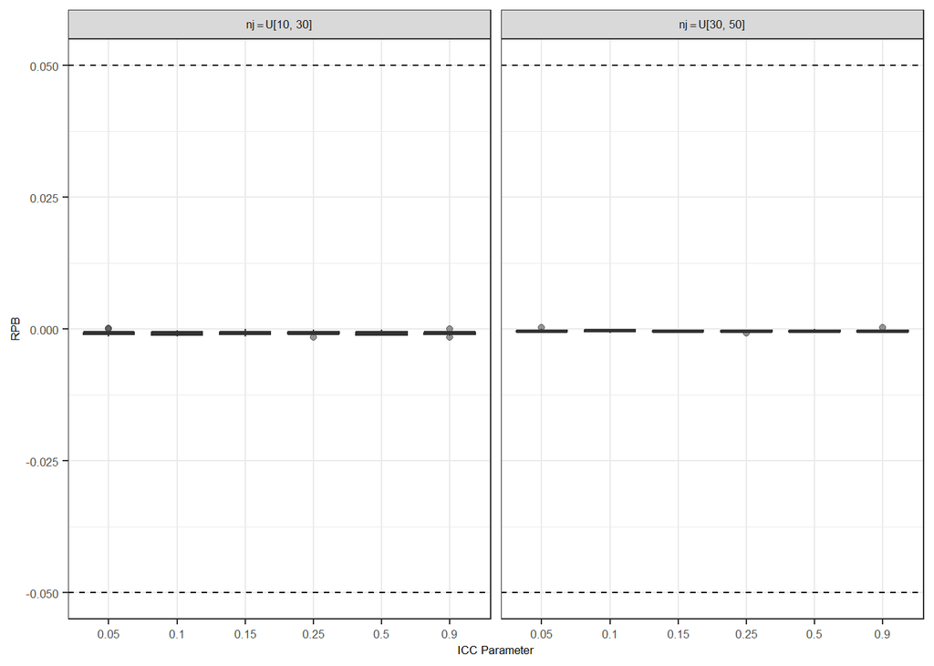

```r
perf_crit2  |> ggplot(aes(x = factor(var_combo_graph), y = rel_bias_res)) +
  geom_hline(yintercept = .05, linetype = "dashed") +
  geom_hline(yintercept = -.05, linetype = "dashed") +
#  geom_hline(yintercept = 0, linetype = "solid", colour = "red") +
  geom_boxplot(alpha = .5) +
  facet_grid(cols = vars(n_bar_size )
             ,
             labeller = label_bquote(cols = nj ==.(n_bar_size))) +
  labs(x = "ICC Parameter", y = "RPB") +
  theme_bw() +
  theme(legend.position = "none",
        axis.text.x = element_text(size = 6.5),
        axis.text.y = element_text(size = 6.5),
      #  plot.caption=element_text(hjust = 0, size = 8),
      #  legend.title=element_text(size = 8),
      #  legend.text=element_text(size = 8),
        axis.title.x = element_text(size=6.5),
        axis.title.y = element_text(size=6.5),
       strip.text.x = element_text(size = 6.5, face="bold"),
        strip.text.y = element_text(size = 6.5, face="bold")
      )
```

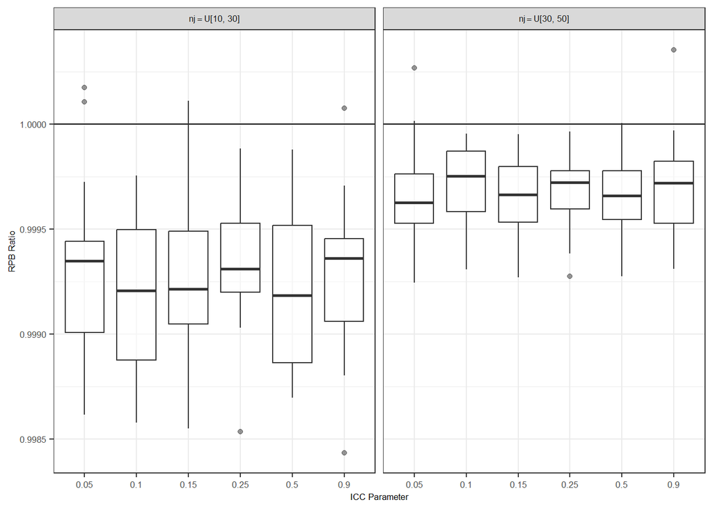

```r
ggsave("RPB_L2_nj_mean.png", width = 6.8, height = 5, units = "in")



perf_crit2  |> ggplot(aes(x = factor(var_combo_graph), y = rel_bias_res_ratio)) +
   geom_hline(yintercept = 1, linetype = "solid") +
  geom_boxplot(alpha = .5) +
  facet_grid(cols = vars(n_bar_size )
             ,
             labeller = label_bquote(cols = nj ==.(n_bar_size))) +
  labs(x = "ICC Parameter", y = "RPB Ratio") +
  theme_bw() +
  theme(legend.position = "none",
        axis.text.x = element_text(size = 6.5),
        axis.text.y = element_text(size = 6.5),
      #  plot.caption=element_text(hjust = 0, size = 8),
      #  legend.title=element_text(size = 8),
      #  legend.text=element_text(size = 8),
        axis.title.x = element_text(size=6.5),
        axis.title.y = element_text(size=6.5),
       strip.text.x = element_text(size = 6.5, face="bold"),
        strip.text.y = element_text(size = 6.5, face="bold")
      )
```

# 6 Evaluating the Distribution ICC estimates

Note for the Fisher TF pooled estimates, they have already been back transformed for all of these analyses.

```r
load("data/results_conv.RData")
load("data/results_pooled_est.RData")
```

# 7 Distributions of the ICC Estimates from primary studies

```r
skewness <- function(x) {

  variance = var(x)
  K = length(x)
  skewness = (1/(K*sqrt(variance)^3)*sum((x-mean(x))^3))

  return(skewness)

}

kurtosis <- function(x) {

  variance = var(x)
  K = length(x)
  kurtosis = (1/(K*variance^2))*sum((x-mean(x))^4)

  return(kurtosis)

}
```

First, which set of conditions resulted in the lowest raw bias and relative bias?

```r
# perf_crit |>group_by(ICC_true) |>slice(which.min(bias_icc)) |> select(ICC_true, method, var_icc_name, icc_est_n, nj_size, n_bar_size, n_bar_prop, tau)
#
# perf_crit |>group_by(ICC_true) |>slice(which.min(rel_bias_icc)) |> select(ICC_true, method, var_icc_name, icc_est_n, nj_size, n_bar_size, n_bar_prop, tau)


results_all_converged_dist_icc_est <- results_all_converged |> filter(icc_est_n == 50) |>filter(nj_size == "U[30, 50]") |>filter(n_bar_size == "U[10, 30]") |>filter(n_bar_prop == 0.1) |>filter(tau == 0.02)


# results_all_converged_dist_icc_est <- results_all_converged |> filter(nj_size == "U[30, 50]") |> filter(n_bar_size == "U[10, 30]") |>
#   filter(n_bar_prop == 0.1) |> filter(tau == 0.02 ) |> filter(icc_est_n == 50)
```

## 7.1 Distribution of ICC estimates when $\rho = 0.05$:

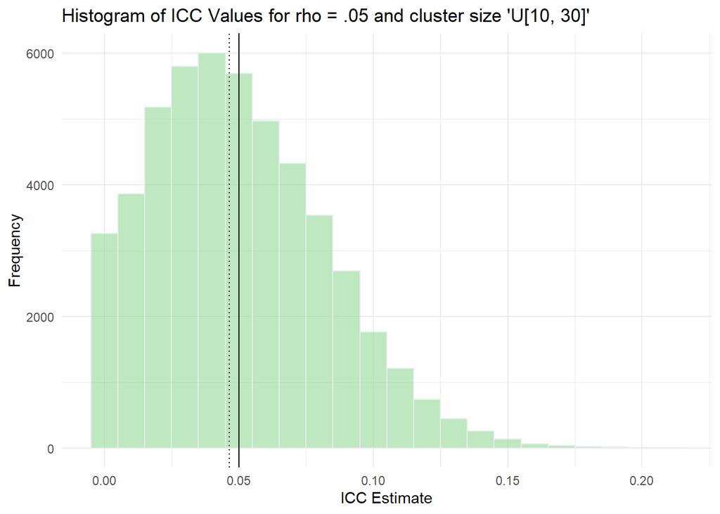

```r
dist_0.05 <- results_all_converged_dist_icc_est |> ungroup() |>filter(var_combo_graph == 0.05) |> select(clustervar, residvar) |> distinct() |>
  mutate(icc_list = map2(clustervar, residvar, ~ map2(.x, .y, ~ .x / (.x +.y)))) |>select(icc_list) |> unnest(icc_list) |> unlist()

dist_0.05 <- data.frame(icc = dist_0.05)

ggplot(dist_0.05 , aes(x = icc)) +
  geom_histogram(fill = "#92D895", color = "#e9ecef", alpha = 0.6, binwidth = 0.01) +
  geom_vline(xintercept = 0.05, linetype = "solid") +
  geom_vline(xintercept = mean(dist_0.05$icc), linetype = "dashed") +
  geom_vline(xintercept = median(dist_0.05$icc), linetype = "dotted") +
  labs(title = "Histogram of ICC Values for rho = .05 and cluster size 'U[10, 30]'", x = "ICC Estimate", y = "Frequency") +
  theme_minimal()
```

This distribution has a mean of 0.0500555, variance of 0.0010352, median of 0.0464974, a skewness of 0.5933149, and kurtosis of 3.1094325.

## 7.2 Distribution of ICC estimates when $\rho = 0.10$:

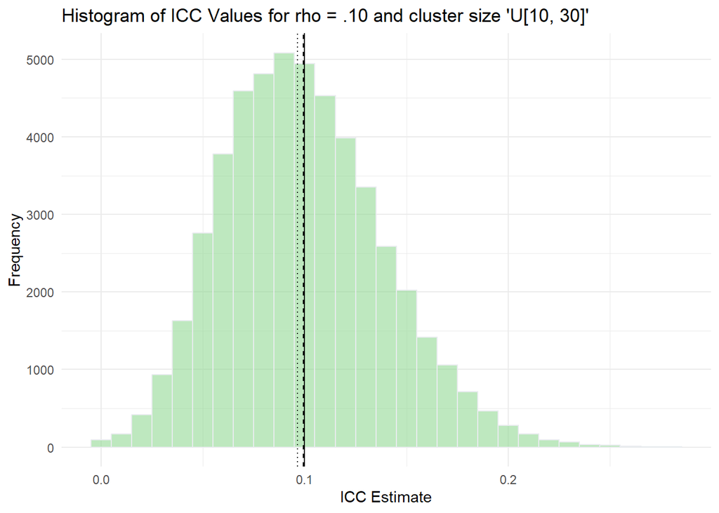

```r
dist_0.10 <- results_all_converged_dist_icc_est |> ungroup() |>filter(var_combo_graph == 0.10) |> select(clustervar, residvar) |> distinct() |>
  mutate(icc_list = map2(clustervar, residvar, ~ map2(.x, .y, ~ .x / (.x +.y)))) |>select(icc_list) |> unnest(icc_list) |> unlist()

dist_0.10 <- data.frame(icc = dist_0.10)

ggplot(dist_0.10 , aes(x = icc)) +
  geom_histogram(fill = "#92D895", color = "#e9ecef", alpha = 0.6, binwidth = 0.01) +
      geom_vline(xintercept = 0.1, linetype = "solid") +
  geom_vline(xintercept = mean(dist_0.10$icc), linetype = "dashed") +
  geom_vline(xintercept = median(dist_0.10$icc), linetype = "dotted") +
  labs(title = "Histogram of ICC Values for rho = .10 and cluster size 'U[10, 30]'", x = "ICC Estimate", y = "Frequency") +
  theme_minimal()
```

This distribution has a mean of 0.0993899, variance of 0.0015262, median of 0.0964493, a skewness of 0.4208593, and kurtosis of 3.1433641.

## 7.3 Distribution of ICC estimates when $\rho = 0.15$:

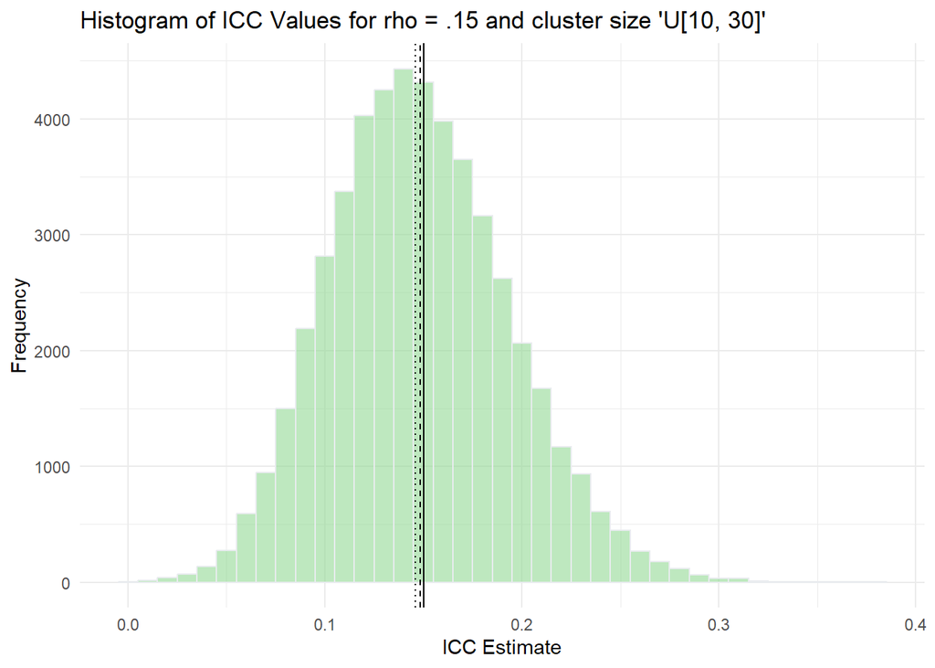

```r
dist_0.15 <- results_all_converged_dist_icc_est |> ungroup() |>filter(var_combo_graph == 0.15) |> select(clustervar, residvar) |> distinct() |>
  mutate(icc_list = map2(clustervar, residvar, ~ map2(.x, .y, ~ .x / (.x +.y)))) |>select(icc_list) |> unnest(icc_list) |> unlist()

dist_0.15 <- data.frame(icc = dist_0.15)

ggplot(dist_0.15 , aes(x = icc)) +
  geom_histogram(fill = "#92D895", color = "#e9ecef", alpha = 0.6, binwidth = 0.01) +
      geom_vline(xintercept = 0.15, linetype = "solid") +
  geom_vline(xintercept = mean(dist_0.15$icc), linetype = "dashed") +
  geom_vline(xintercept = median(dist_0.15$icc), linetype = "dotted") +
  labs(title = "Histogram of ICC Values for rho = .15 and cluster size 'U[10, 30]'", x = "ICC Estimate", y = "Frequency") +
  theme_minimal()
```

This distribution has a mean of 0.1482727, variance of 0.0020559, median of 0.1457706, a skewness of 0.3036363, and kurtosis of 3.0933228.

## 7.4 Distribution of ICC estimates when $\rho = 0.25$:

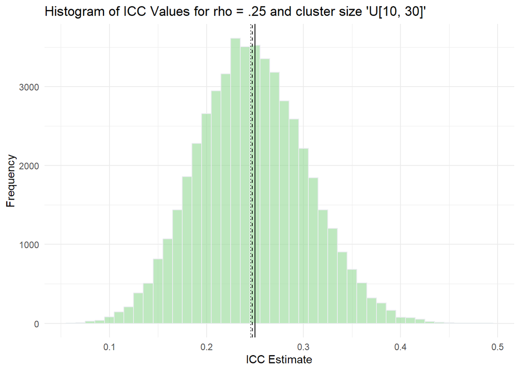

```r
dist_0.25 <- results_all_converged_dist_icc_est |> ungroup() |>filter(var_combo_graph == 0.25) |> select(clustervar, residvar) |> distinct() |>
  mutate(icc_list = map2(clustervar, residvar, ~ map2(.x, .y, ~ .x / (.x +.y)))) |>select(icc_list) |> unnest(icc_list) |> unlist()

dist_0.25 <- data.frame(icc = dist_0.25 )

ggplot(dist_0.25 , aes(x = icc)) +
  geom_histogram(fill = "#92D895", color = "#e9ecef", alpha = 0.6, binwidth = 0.01) +
  geom_vline(xintercept = 0.25, linetype = "solid") +
  geom_vline(xintercept = mean(dist_0.25$icc), linetype = "dashed") +
  geom_vline(xintercept = median(dist_0.25$icc), linetype = "dotted") +
  labs(title = "Histogram of ICC Values for rho = .25 and cluster size 'U[10, 30]'", x = "ICC Estimate", y = "Frequency") +
  theme_minimal()
```

This distribution has a mean of 0.2471755, variance of 0.0031014, median of 0.245689, a skewness of 0.140802, and kurtosis of 2.9323949.

## 7.5 Distribution of ICC estimates when $\rho = 0.50$:

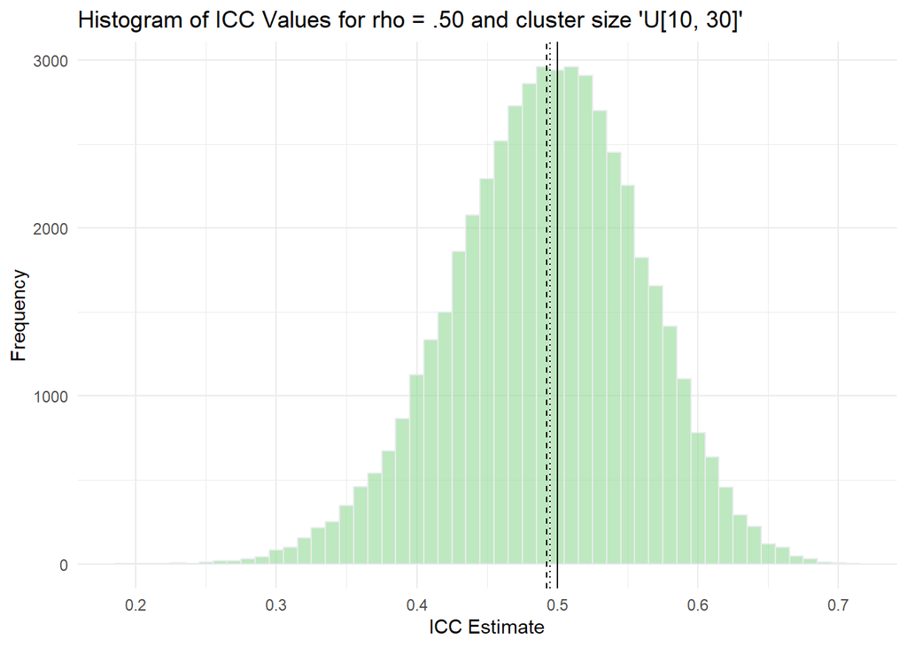

```r
dist_0.5 <- results_all_converged_dist_icc_est |> ungroup() |>filter(var_combo_graph == 0.5) |> select(clustervar, residvar) |> distinct() |>
  mutate(icc_list = map2(clustervar, residvar, ~ map2(.x, .y, ~ .x / (.x +.y)))) |>select(icc_list) |> unnest(icc_list) |> unlist()

dist_0.5 <- data.frame(icc = dist_0.5 )

ggplot(dist_0.5 , aes(x = icc)) +
 geom_histogram(fill = "#92D895", color = "#e9ecef", alpha = 0.6, binwidth = 0.01) +
  geom_vline(xintercept = 0.50, linetype = "solid") +
  geom_vline(xintercept = mean(dist_0.5$icc), linetype = "dashed") +
  geom_vline(xintercept = median(dist_0.5$icc), linetype = "dotted") +
  labs(title = "Histogram of ICC Values for rho = .50 and cluster size 'U[10, 30]'", x = "ICC Estimate", y = "Frequency") +
  theme_minimal()
```

This distribution has a mean of 0.4923617, variance of 0.0044361, median of 0.4947604, a skewness of -0.2104669, and kurtosis of 3.0122678.

compare this to a distribution that has the larger average cluster sizes condition:

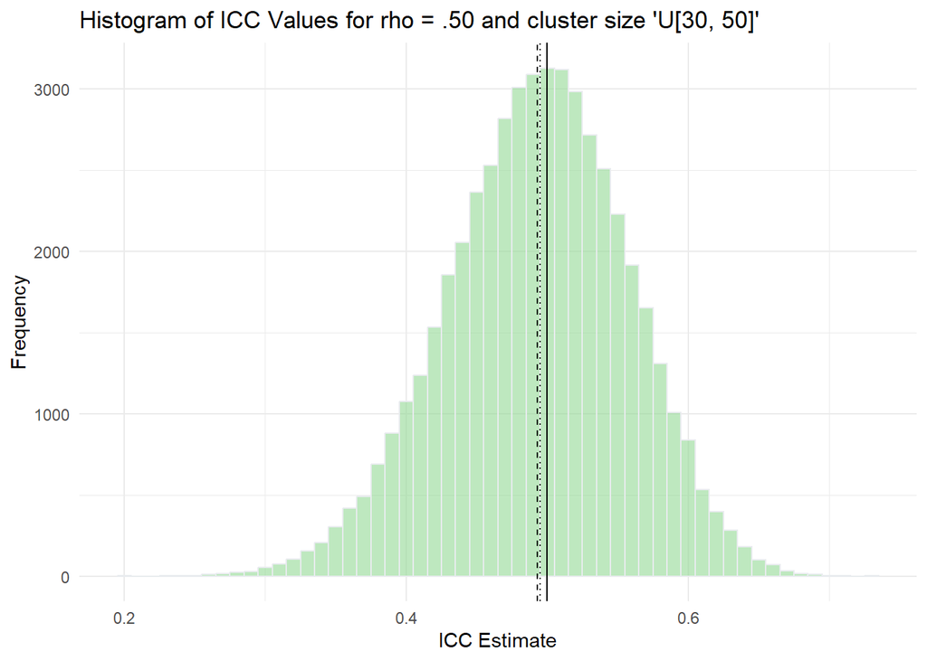

```r
results_all_converged_dist_icc_est2 <- results_all_converged |> filter(nj_size == "U[30, 50]") |> filter(n_bar_size == "U[30, 50]") |>
  filter(n_bar_prop == 0.1) |> filter(tau == 0.02   ) |> filter(icc_est_n == 50)

dist_0.5 <- results_all_converged_dist_icc_est2 |> ungroup() |> filter(var_combo_graph == 0.50) |> select(clustervar, residvar) |> distinct() |>
  mutate(icc_list = map2(clustervar, residvar, ~ map2(.x, .y, ~ .x / (.x +.y)))) |>select(icc_list) |> unnest(icc_list) |> unlist()

dist_0.5 <- data.frame(icc = dist_0.5)

ggplot(dist_0.5 , aes(x = icc)) +
  geom_histogram(fill = "#92D895", color = "#e9ecef", alpha = 0.6, binwidth = 0.01) +
  geom_vline(xintercept = 0.50, linetype = "solid") +
  geom_vline(xintercept = mean(dist_0.5$icc), linetype = "dashed") +
  geom_vline(xintercept = median(dist_0.5$icc), linetype = "dotted") +
  labs(title = "Histogram of ICC Values for rho = .50 and cluster size 'U[30, 50]'", x = "ICC Estimate", y = "Frequency") +
  theme_minimal()
```

This distribution has a mean of 0.4928036, variance of 0.0040805, median of 0.4950266, a skewness of -0.1914525, and kurtosis of 2.9920759.

## 7.6 Distribution of ICC estimates when $\rho = 0.90$:

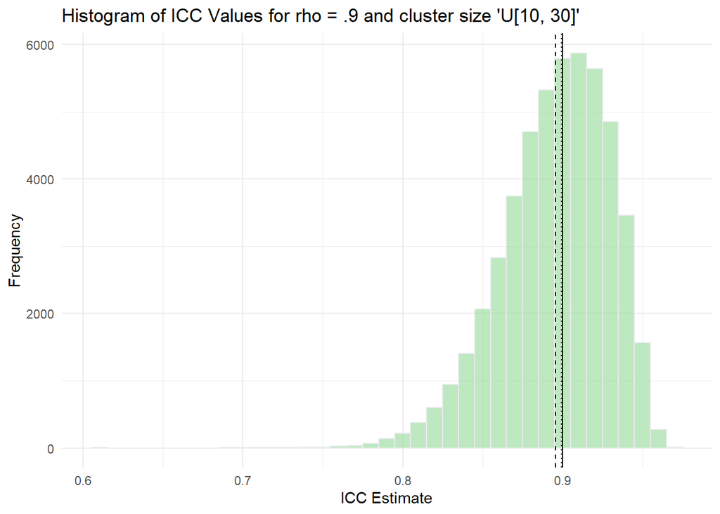

```r
dist_0.9 <- results_all_converged_dist_icc_est |> ungroup() |>filter(var_combo_graph == 0.9) |> select(clustervar, residvar) |> distinct() |>
  mutate(icc_list = map2(clustervar, residvar, ~ map2(.x, .y, ~ .x / (.x +.y)))) |>select(icc_list) |> unnest(icc_list) |> unlist()

dist_0.9 <- data.frame(icc = dist_0.9)

ggplot(dist_0.9 , aes(x = icc)) +
  geom_histogram(fill = "#92D895", color = "#e9ecef", alpha = 0.6, binwidth = 0.01) +
  geom_vline(xintercept = 0.9, linetype = "solid") +
  geom_vline(xintercept = mean(dist_0.9$icc), linetype = "dashed") +
  geom_vline(xintercept = median(dist_0.9$icc), linetype = "dotted") +
  labs(title = "Histogram of ICC Values for rho = .9 and cluster size 'U[10, 30]'", x = "ICC Estimate", y = "Frequency") +
  theme_minimal()
```

This distribution has a mean of 0.8956405, variance of 0.0011112, median of 0.8993834, a skewness of -0.691453, and kurtosis of 3.6654658.

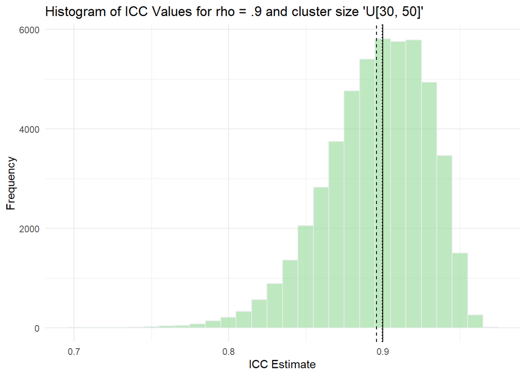

```r
dist_0.9 <- results_all_converged_dist_icc_est2 |> ungroup() |>filter(var_combo_graph == 0.9) |> select(clustervar, residvar) |> distinct() |>
  mutate(icc_list = map2(clustervar, residvar, ~ map2(.x, .y, ~ .x / (.x +.y)))) |>select(icc_list) |> unnest(icc_list) |> unlist()

dist_0.9 <- data.frame(icc = dist_0.9)

ggplot(dist_0.9 , aes(x = icc)) +
  geom_histogram(fill = "#92D895", color = "#e9ecef", alpha = 0.6, binwidth = 0.01) +
  geom_vline(xintercept = 0.9, linetype = "solid") +
  geom_vline(xintercept = mean(dist_0.9$icc), linetype = "dashed") +
  geom_vline(xintercept = median(dist_0.9$icc), linetype = "dotted") +
  labs(title = "Histogram of ICC Values for rho = .9 and cluster size 'U[30, 50]'" , x = "ICC Estimate", y = "Frequency") +
  theme_minimal()
```

# 8 Distributions of the Pooled ICC estimates

## 8.1 $\rho = 0.05$:

```r
results_all_converged |> filter(var_combo_graph == 0.05) |>
  group_by(variance, model) |>
  summarise(K = n(),
            "Mean Pooled Estimate" = mean(pooled_icc_est),
            var_est = var(pooled_icc_est),
            "Raw Bias Pooled Estimate" = mean(pooled_icc_est) - 0.05,
            "MCSE Raw Bias" = sqrt(var_est / K),
            RMSE = sqrt(sum((pooled_icc_est - 0.05)^2) / K),
            min_est = min(pooled_icc_est),
            max_est = max(pooled_icc_est),
            .groups = "drop")|>
  kbl() |>
  kable_styling() |>
  scroll_box(width = "900px", height = "500px")
```

| variance | model | K | Mean Pooled Estimate | var_est | Raw Bias Pooled Estimate | MCSE Raw Bias | RMSE | min_est | max_est |
| --- | --- | --- | --- | --- | --- | --- | --- | --- | --- |
| Donner | REML | 48000 | 0.0444794 | 1.93e-05 | -0.0055206 | 2.00e-05 | 0.0070531 | 0.0194512 | 0.0689376 |
| Donner | RVE | 48000 | 0.0444223 | 1.95e-05 | -0.0055777 | 2.02e-05 | 0.0071169 | 0.0197097 | 0.0696369 |
| Fisher | REML | 48000 | 0.0444866 | 1.93e-05 | -0.0055134 | 2.00e-05 | 0.0070468 | 0.0197216 | 0.0690194 |
| Fisher | RVE | 48000 | 0.0444274 | 1.95e-05 | -0.0055726 | 2.02e-05 | 0.0071105 | 0.0198642 | 0.0696210 |
| Fisher TF | REML | 48000 | 0.0461986 | 1.67e-05 | -0.0038014 | 1.87e-05 | 0.0055821 | 0.0241912 | 0.0702339 |
| Fisher TF | RVE | 48000 | 0.0461986 | 1.67e-05 | -0.0038014 | 1.87e-05 | 0.0055822 | 0.0241917 | 0.0702424 |
| Hedges | REML | 48000 | 0.0445867 | 1.92e-05 | -0.0054133 | 2.00e-05 | 0.0069609 | 0.0196622 | 0.0691946 |
| Hedges | RVE | 48000 | 0.0445332 | 1.94e-05 | -0.0054668 | 2.01e-05 | 0.0070212 | 0.0199373 | 0.0698602 |
| Smith | REML | 48000 | 0.0443622 | 1.94e-05 | -0.0056378 | 2.01e-05 | 0.0071521 | 0.0195930 | 0.0687574 |
| Smith | RVE | 48000 | 0.0443009 | 1.96e-05 | -0.0056991 | 2.02e-05 | 0.0072169 | 0.0196059 | 0.0693541 |
| Swiger | REML | 48000 | 0.0444893 | 1.93e-05 | -0.0055107 | 2.00e-05 | 0.0070442 | 0.0197166 | 0.0690243 |
| Swiger | RVE | 48000 | 0.0444302 | 1.95e-05 | -0.0055698 | 2.02e-05 | 0.0071078 | 0.0198623 | 0.0696227 |

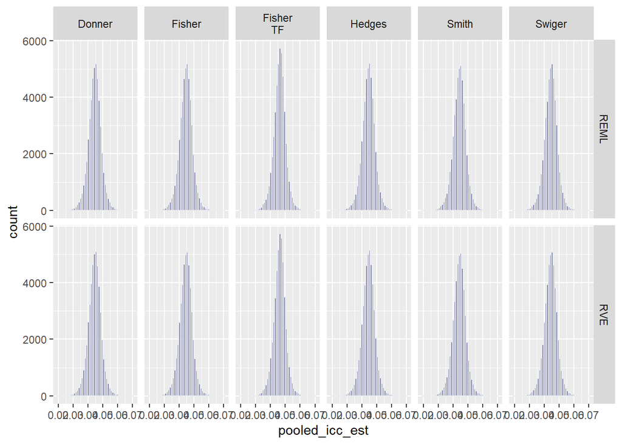

```r
results_all_converged |> filter(var_combo_graph == 0.05) |>
#  group_by(var_combo_graph) |>
  ggplot(aes(x = pooled_icc_est)) +
  geom_histogram( fill = "#404080", color = "#e9ecef", alpha = 0.6, position = 'identity', bins = 50) +
    facet_grid(model ~ variance)
```

## 8.2 $\rho = 0.10$:

```r
results_all_converged |> filter(var_combo_graph == 0.10) |>
  group_by(variance, model) |>
  summarise(K = n(),
            "Mean Pooled Estimate" = mean(pooled_icc_est),
            var_est = var(pooled_icc_est),
            "Raw Bias Pooled Estimate" = mean(pooled_icc_est) - 0.10,
            "MCSE Raw Bias" = sqrt(var_est / K),
            RMSE = sqrt(sum((pooled_icc_est - 0.10)^2) / K),
            min_est = min(pooled_icc_est),
            max_est = max(pooled_icc_est),
            .groups = "drop")|>
  kbl() |>
  kable_styling() |>
  scroll_box(width = "900px", height = "500px")
```

| variance | model | K | Mean Pooled Estimate | var_est | Raw Bias Pooled Estimate | MCSE Raw Bias | RMSE | min_est | max_est |
| --- | --- | --- | --- | --- | --- | --- | --- | --- | --- |
| Donner | REML | 48000 | 0.0929020 | 2.93e-05 | -0.0070980 | 2.47e-05 | 0.0089287 | 0.0638537 | 0.1205014 |
| Donner | RVE | 48000 | 0.0929014 | 2.93e-05 | -0.0070986 | 2.47e-05 | 0.0089284 | 0.0637351 | 0.1203858 |
| Fisher | REML | 48000 | 0.0928594 | 2.95e-05 | -0.0071406 | 2.48e-05 | 0.0089687 | 0.0636333 | 0.1204919 |
| Fisher | RVE | 48000 | 0.0928520 | 2.95e-05 | -0.0071480 | 2.48e-05 | 0.0089749 | 0.0635221 | 0.1203793 |
| Fisher TF | REML | 48000 | 0.0950363 | 2.59e-05 | -0.0049637 | 2.32e-05 | 0.0071069 | 0.0673182 | 0.1239894 |
| Fisher TF | RVE | 48000 | 0.0950365 | 2.59e-05 | -0.0049635 | 2.32e-05 | 0.0071069 | 0.0673183 | 0.1239837 |
| Hedges | REML | 48000 | 0.0930215 | 2.93e-05 | -0.0069785 | 2.47e-05 | 0.0088291 | 0.0640675 | 0.1205711 |
| Hedges | RVE | 48000 | 0.0930298 | 2.92e-05 | -0.0069702 | 2.47e-05 | 0.0088208 | 0.0639626 | 0.1204625 |
| Smith | REML | 48000 | 0.0926788 | 2.97e-05 | -0.0073212 | 2.49e-05 | 0.0091247 | 0.0636260 | 0.1202392 |
| Smith | RVE | 48000 | 0.0926590 | 2.97e-05 | -0.0073410 | 2.49e-05 | 0.0091417 | 0.0635153 | 0.1200836 |
| Swiger | REML | 48000 | 0.0928633 | 2.94e-05 | -0.0071367 | 2.48e-05 | 0.0089651 | 0.0636440 | 0.1204934 |
| Swiger | RVE | 48000 | 0.0928562 | 2.94e-05 | -0.0071438 | 2.48e-05 | 0.0089710 | 0.0635328 | 0.1203808 |

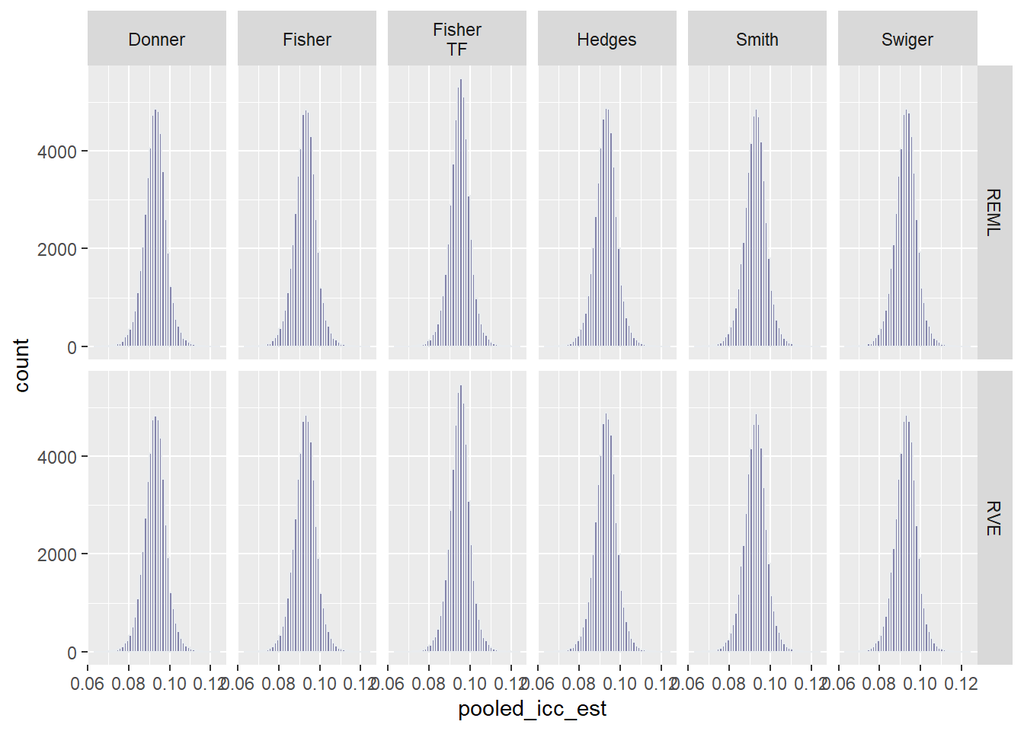

```r
results_all_converged |> filter(var_combo_graph == 0.1) |>
#  group_by(var_combo_graph) |>
  ggplot(aes(x = pooled_icc_est)) +
  geom_histogram( fill = "#404080", color = "#e9ecef", alpha = 0.6, position = 'identity', bins = 50) +
    facet_grid(model ~ variance)
```

## 8.3 $\rho = 0.15$:

```r
results_all_converged |> filter(var_combo_graph == 0.15) |>
  group_by(variance, model) |>
  summarise(K = n(),
            "Mean Pooled Estimate" = mean(pooled_icc_est),
            var_est = var(pooled_icc_est),
            "Raw Bias Pooled Estimate" = mean(pooled_icc_est) - 0.15,
            "MCSE Raw Bias" = sqrt(var_est / K),
            RMSE = sqrt(sum((pooled_icc_est - 0.15)^2) / K),
            min_est = min(pooled_icc_est),
            max_est = max(pooled_icc_est),
            .groups = "drop")|>
  kbl() |>
  kable_styling() |>
  scroll_box(width = "900px", height = "500px")
```

| variance | model | K | Mean Pooled Estimate | var_est | Raw Bias Pooled Estimate | MCSE Raw Bias | RMSE | min_est | max_est |
| --- | --- | --- | --- | --- | --- | --- | --- | --- | --- |
| Donner | REML | 48000 | 0.1418869 | 4.15e-05 | -0.0081131 | 2.94e-05 | 0.0103601 | 0.1064030 | 0.1766836 |
| Donner | RVE | 48000 | 0.1418123 | 4.17e-05 | -0.0081877 | 2.95e-05 | 0.0104256 | 0.1063915 | 0.1766836 |
| Fisher | REML | 48000 | 0.1418120 | 4.17e-05 | -0.0081880 | 2.95e-05 | 0.0104287 | 0.1063188 | 0.1766414 |
| Fisher | RVE | 48000 | 0.1417274 | 4.19e-05 | -0.0082726 | 2.95e-05 | 0.0105041 | 0.1063003 | 0.1766414 |
| Fisher TF | REML | 48000 | 0.1436102 | 3.84e-05 | -0.0063898 | 2.83e-05 | 0.0089018 | 0.1106306 | 0.1773362 |
| Fisher TF | RVE | 48000 | 0.1436106 | 3.84e-05 | -0.0063894 | 2.83e-05 | 0.0089014 | 0.1106319 | 0.1773445 |
| Hedges | REML | 48000 | 0.1420110 | 4.14e-05 | -0.0079890 | 2.94e-05 | 0.0102592 | 0.1068142 | 0.1768486 |
| Hedges | RVE | 48000 | 0.1419499 | 4.15e-05 | -0.0080501 | 2.94e-05 | 0.0103125 | 0.1068147 | 0.1768486 |
| Smith | REML | 48000 | 0.1416008 | 4.20e-05 | -0.0083992 | 2.96e-05 | 0.0106104 | 0.1056585 | 0.1765680 |
| Smith | RVE | 48000 | 0.1414930 | 4.23e-05 | -0.0085070 | 2.97e-05 | 0.0107085 | 0.1056643 | 0.1765680 |
| Swiger | REML | 48000 | 0.1418164 | 4.17e-05 | -0.0081836 | 2.95e-05 | 0.0104245 | 0.1063331 | 0.1766487 |
| Swiger | RVE | 48000 | 0.1417324 | 4.19e-05 | -0.0082676 | 2.95e-05 | 0.0104994 | 0.1063149 | 0.1766487 |

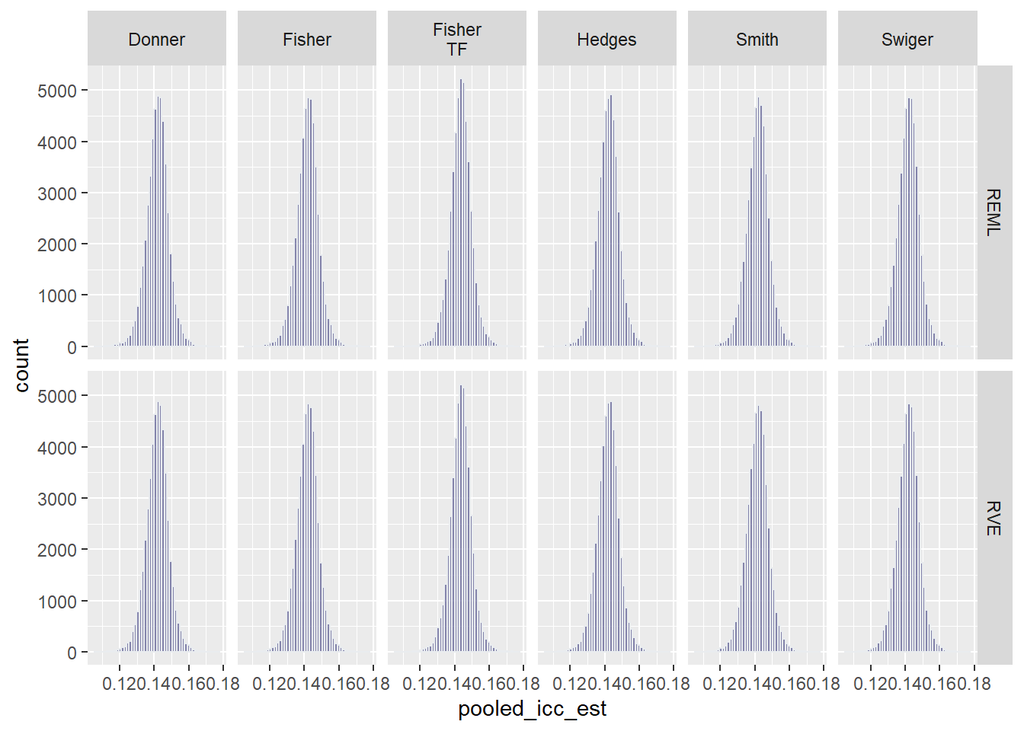

```r
results_all_converged |>
  filter(var_combo_graph == 0.15) |>
#  group_by(var_combo_graph) |>
  ggplot(aes(x = pooled_icc_est)) +
  geom_histogram( fill = "#404080", color = "#e9ecef", alpha = 0.6, position = 'identity', bins = 50) +
    facet_grid(model~ variance)
```

## 8.4 $\rho = 0.25$:

```r
results_all_converged |> filter(var_combo_graph == 0.25) |>
  group_by(variance, model) |>
  summarise(K = n(),
            "Mean Pooled Estimate" = mean(pooled_icc_est),
            var_est = var(pooled_icc_est),
            "Raw Bias Pooled Estimate" = mean(pooled_icc_est) - 0.25,
            "MCSE Raw Bias" = sqrt(var_est / K),
            RMSE = sqrt(sum((pooled_icc_est - 0.25)^2) / K),
            min_est = min(pooled_icc_est),
            max_est = max(pooled_icc_est),
            .groups = "drop")|>

  kbl() |>
  kable_styling() |>
  scroll_box(width = "900px", height = "500px")
```

| variance | model | K | Mean Pooled Estimate | var_est | Raw Bias Pooled Estimate | MCSE Raw Bias | RMSE | min_est | max_est |
| --- | --- | --- | --- | --- | --- | --- | --- | --- | --- |
| Donner | REML | 48000 | 0.2413431 | 6.46e-05 | -0.0086569 | 3.67e-05 | 0.0118127 | 0.2013939 | 0.2871551 |
| Donner | RVE | 48000 | 0.2411995 | 6.50e-05 | -0.0088005 | 3.68e-05 | 0.0119352 | 0.2016610 | 0.2870117 |
| Fisher | REML | 48000 | 0.2412389 | 6.49e-05 | -0.0087611 | 3.68e-05 | 0.0119028 | 0.2012907 | 0.2869823 |
| Fisher | RVE | 48000 | 0.2410835 | 6.54e-05 | -0.0089165 | 3.69e-05 | 0.0120371 | 0.2013082 | 0.2868213 |
| Fisher TF | REML | 48000 | 0.2410603 | 6.57e-05 | -0.0089397 | 3.70e-05 | 0.0120662 | 0.1997265 | 0.2822733 |
| Fisher TF | RVE | 48000 | 0.2410612 | 6.57e-05 | -0.0089388 | 3.70e-05 | 0.0120653 | 0.1997266 | 0.2822763 |
| Hedges | REML | 48000 | 0.2414566 | 6.45e-05 | -0.0085434 | 3.67e-05 | 0.0117264 | 0.2011547 | 0.2875039 |
| Hedges | RVE | 48000 | 0.2413259 | 6.49e-05 | -0.0086741 | 3.68e-05 | 0.0118374 | 0.2017192 | 0.2873750 |
| Smith | REML | 48000 | 0.2410222 | 6.54e-05 | -0.0089778 | 3.69e-05 | 0.0120820 | 0.2012777 | 0.2869650 |
| Smith | RVE | 48000 | 0.2408420 | 6.60e-05 | -0.0091580 | 3.71e-05 | 0.0122404 | 0.2012916 | 0.2868021 |
| Swiger | REML | 48000 | 0.2412436 | 6.49e-05 | -0.0087564 | 3.68e-05 | 0.0118986 | 0.2012878 | 0.2869940 |
| Swiger | RVE | 48000 | 0.2410888 | 6.54e-05 | -0.0089112 | 3.69e-05 | 0.0120324 | 0.2013215 | 0.2868341 |

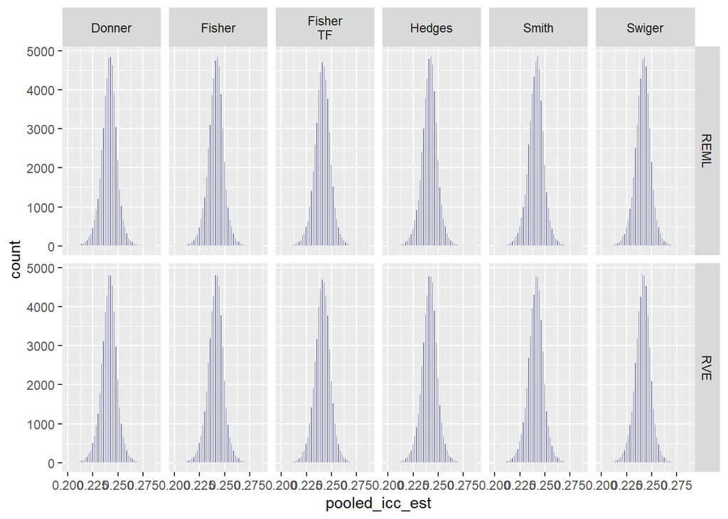

```r
results_all_converged |>
  filter(var_combo_graph == 0.25) |>
#  group_by(var_combo_graph) |>
  ggplot(aes(x = pooled_icc_est)) +
  geom_histogram( fill = "#404080", color = "#e9ecef", alpha = 0.6, position = 'identity', bins = 50) +
    facet_grid(model~ variance)
```

## 8.5 $\rho = 0.50$:

```r
results_all_converged |>
  filter(var_combo_graph == 0.50) |>
  group_by(variance, model) |>
  summarise(K = n(),
            "Mean Pooled Estimate" = mean(pooled_icc_est),
      #      "Median Pooled Estimate" = median(pooled_icc_est),
            var_est = var(pooled_icc_est),
            "Raw Bias Pooled Estimate" = mean(pooled_icc_est) - 0.50,
            "MCSE Raw Bias" = sqrt(var_est / K),
            RMSE = sqrt(sum((pooled_icc_est - 0.50)^2) / K),
            min_est = min(pooled_icc_est),
            max_est = max(pooled_icc_est),
            .groups = "drop")|>
  kbl() |>
  kable_styling() |>
  scroll_box(width = "900px", height = "500px")
```

| variance | model | K | Mean Pooled Estimate | var_est | Raw Bias Pooled Estimate | MCSE Raw Bias | RMSE | min_est | max_est |
| --- | --- | --- | --- | --- | --- | --- | --- | --- | --- |
| Donner | REML | 48000 | 0.4953113 | 0.0000912 | -0.0046887 | 4.36e-05 | 0.0106376 | 0.4411449 | 0.5419561 |
| Donner | RVE | 48000 | 0.4953182 | 0.0000913 | -0.0046818 | 4.36e-05 | 0.0106394 | 0.4411045 | 0.5420179 |
| Fisher | REML | 48000 | 0.4952857 | 0.0000913 | -0.0047143 | 4.36e-05 | 0.0106546 | 0.4410808 | 0.5419028 |
| Fisher | RVE | 48000 | 0.4952923 | 0.0000914 | -0.0047077 | 4.36e-05 | 0.0106570 | 0.4410339 | 0.5419671 |
| Fisher TF | REML | 48000 | 0.4880025 | 0.0001072 | -0.0119975 | 4.73e-05 | 0.0158473 | 0.4341028 | 0.5367767 |
| Fisher TF | RVE | 48000 | 0.4880040 | 0.0001072 | -0.0119960 | 4.73e-05 | 0.0158458 | 0.4340954 | 0.5367603 |
| Hedges | REML | 48000 | 0.4953049 | 0.0000911 | -0.0046951 | 4.36e-05 | 0.0106353 | 0.4412048 | 0.5418731 |
| Hedges | RVE | 48000 | 0.4953117 | 0.0000912 | -0.0046883 | 4.36e-05 | 0.0106370 | 0.4411663 | 0.5419321 |
| Smith | REML | 48000 | 0.4952682 | 0.0000915 | -0.0047318 | 4.37e-05 | 0.0106725 | 0.4411312 | 0.5421544 |
| Smith | RVE | 48000 | 0.4952744 | 0.0000916 | -0.0047256 | 4.37e-05 | 0.0106756 | 0.4409836 | 0.5422489 |
| Swiger | REML | 48000 | 0.4952861 | 0.0000913 | -0.0047139 | 4.36e-05 | 0.0106541 | 0.4410833 | 0.5419024 |
| Swiger | RVE | 48000 | 0.4952927 | 0.0000914 | -0.0047073 | 4.36e-05 | 0.0106565 | 0.4410366 | 0.5419665 |

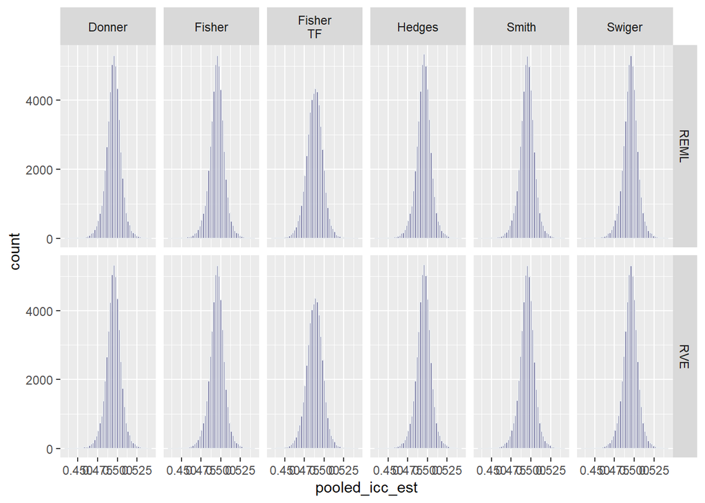

```r
results_all_converged |>
  filter(var_combo_graph == 0.5) |>
#  group_by(var_combo_graph) |>
  ggplot(aes(x = pooled_icc_est)) +
  geom_histogram( fill = "#404080", color = "#e9ecef", alpha = 0.6, position = 'identity', bins = 50) +
    facet_grid(model ~ variance)
```

## 8.6 $\rho = 0.90$:

```r
results_all_converged |> filter(var_combo_graph == 0.90) |>
  group_by(variance, model) |>
  summarise(K = n(),
            "Mean Pooled Estimate" = mean(pooled_icc_est),
      #      "Median Pooled Estimate" = median(pooled_icc_est),
            var_est = var(pooled_icc_est),
            "Raw Bias Pooled Estimate" = mean(pooled_icc_est) - 0.90,
            "MCSE Raw Bias" = sqrt(var_est / K),
            RMSE = sqrt(sum((pooled_icc_est - 0.90)^2) / K),
            min_est = min(pooled_icc_est),
            max_est = max(pooled_icc_est),
            .groups = "drop")|>
  kbl() |>
  kable_styling() |>
  scroll_box(width = "900px", height = "500px")
```

| variance | model | K | Mean Pooled Estimate | var_est | Raw Bias Pooled Estimate | MCSE Raw Bias | RMSE | min_est | max_est |
| --- | --- | --- | --- | --- | --- | --- | --- | --- | --- |
| Donner | REML | 48000 | 0.9026873 | 1.98e-05 | 0.0026873 | 2.03e-05 | 0.0051952 | 0.8735445 | 0.9278472 |
| Donner | RVE | 48000 | 0.9026360 | 1.98e-05 | 0.0026360 | 2.03e-05 | 0.0051716 | 0.8732500 | 0.9277722 |
| Fisher | REML | 48000 | 0.9027883 | 1.99e-05 | 0.0027883 | 2.03e-05 | 0.0052565 | 0.8735703 | 0.9280164 |
| Fisher | RVE | 48000 | 0.9027390 | 1.99e-05 | 0.0027390 | 2.03e-05 | 0.0052311 | 0.8732787 | 0.9279004 |
| Fisher TF | REML | 48000 | 0.8970148 | 2.40e-05 | -0.0029852 | 2.24e-05 | 0.0057375 | 0.8673503 | 0.9201010 |
| Fisher TF | RVE | 48000 | 0.8970153 | 2.40e-05 | -0.0029847 | 2.24e-05 | 0.0057371 | 0.8673525 | 0.9201015 |
| Hedges | REML | 48000 | 0.9025850 | 1.98e-05 | 0.0025850 | 2.03e-05 | 0.0051422 | 0.8735030 | 0.9274451 |
| Hedges | RVE | 48000 | 0.9025347 | 1.98e-05 | 0.0025347 | 2.03e-05 | 0.0051211 | 0.8732056 | 0.9274583 |
| Smith | REML | 48000 | 0.9029853 | 2.00e-05 | 0.0029853 | 2.04e-05 | 0.0053753 | 0.8738152 | 0.9280318 |
| Smith | RVE | 48000 | 0.9029397 | 2.00e-05 | 0.0029397 | 2.04e-05 | 0.0053475 | 0.8735355 | 0.9279116 |
| Swiger | REML | 48000 | 0.9027842 | 1.99e-05 | 0.0027842 | 2.03e-05 | 0.0052539 | 0.8735697 | 0.9280039 |
| Swiger | RVE | 48000 | 0.9027347 | 1.99e-05 | 0.0027347 | 2.03e-05 | 0.0052285 | 0.8732780 | 0.9278907 |

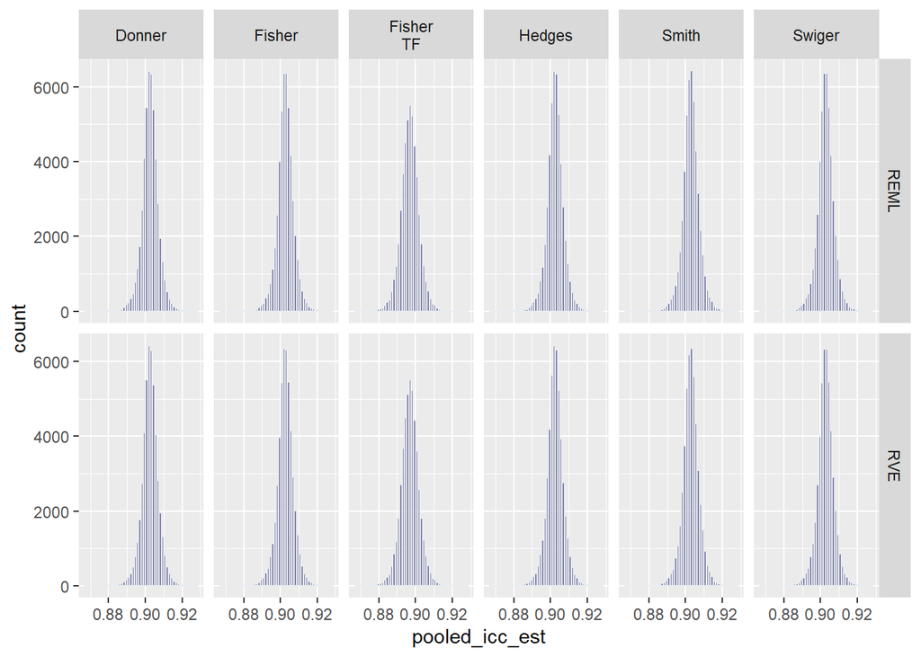

```r
results_all_converged |>
  filter(var_combo_graph == 0.9) |>
#  group_by(var_combo_graph) |>
  ggplot(aes(x = pooled_icc_est)) +
  geom_histogram( fill = "#404080", color = "#e9ecef", alpha = 0.6, position = 'identity', bins = 50) +
    facet_grid(model ~ variance)
```

## 8.7 Skewness and Kurtosis

```r
perf_crit |>
  group_by(variance, model, var_combo_graph) |>
  summarise(m_s = mean(skewness),
          #  min_s = min(skewness),
          #  max_s = max(skewness),
            m_k = mean(kurtosis),
          #  min_k = min(kurtosis),
          #  max_k = max(kurtosis)
          .groups = "drop")|>
  pivot_wider(names_from = variance, values_from = c(m_s, m_k)) |>
  kable(booktabs = TRUE, col.names = c("Model",
                    "ICC Value",
                    "Donner",
                    "Fisher",
                    "Fisher TF",
                    "Hedges",
                    "Smith",
                    "Swiger",
                    "Donner",
                    "Fisher",
                    "Fisher TF",
                    "Hedges",
                    "Smith",
                    "Swiger"
                    )) |>
  kable_styling() |>
  add_header_above(c(" " = 2, "Mean Skewness" = 6, "Mean Kurtosis" = 6)) |>
  column_spec(9:14, bold = T, background = "grey")
```

| Model | ICC Value | Mean Skewness Donner | Mean Skewness Fisher | Mean Skewness Fisher TF | Mean Skewness Hedges | Mean Skewness Smith | Mean Skewness Swiger | Mean Kurtosis Donner | Mean Kurtosis Fisher | Mean Kurtosis Fisher TF | Mean Kurtosis Hedges | Mean Kurtosis Smith | Mean Kurtosis Swiger |
| --- | --- | --- | --- | --- | --- | --- | --- | --- | --- | --- | --- | --- | --- |
| REML | 0.05 | 0.0592022 | 0.0594254 | 0.0866294 | 0.0593649 | 0.0591826 | 0.0594198 | 2.954853 | 2.955471 | 2.953104 | 2.954562 | 2.955909 | 2.955497 |
| REML | 0.10 | 0.0723233 | 0.0724675 | 0.0749330 | 0.0718898 | 0.0727667 | 0.0724434 | 3.001821 | 3.001935 | 2.995341 | 3.001267 | 3.002176 | 3.001900 |
| REML | 0.15 | 0.0357151 | 0.0359730 | 0.0377721 | 0.0360568 | 0.0364047 | 0.0359696 | 2.947726 | 2.948172 | 2.955624 | 2.947198 | 2.948294 | 2.948137 |
| REML | 0.25 | 0.0323212 | 0.0323009 | 0.0280801 | 0.0319869 | 0.0327775 | 0.0322975 | 3.010076 | 3.009571 | 3.014416 | 3.008855 | 3.010905 | 3.009555 |
| REML | 0.50 | -0.0362609 | -0.0361881 | -0.0318783 | -0.0357684 | -0.0362934 | -0.0361812 | 2.980498 | 2.980601 | 2.978749 | 2.980647 | 2.980997 | 2.980596 |
| REML | 0.90 | -0.0973374 | -0.0970725 | -0.1078941 | -0.0969041 | -0.0974283 | -0.0970904 | 3.027450 | 3.027156 | 3.022494 | 3.027109 | 3.026623 | 3.027172 |
| RVE | 0.05 | 0.0684156 | 0.0684702 | 0.0866546 | 0.0682543 | 0.0689004 | 0.0684497 | 2.951688 | 2.952241 | 2.953011 | 2.951607 | 2.952394 | 2.952227 |
| RVE | 0.10 | 0.0742096 | 0.0746966 | 0.0749193 | 0.0736681 | 0.0752857 | 0.0746794 | 2.998217 | 2.998166 | 2.995317 | 2.997296 | 2.998940 | 2.998164 |
| RVE | 0.15 | 0.0359919 | 0.0364623 | 0.0378290 | 0.0359824 | 0.0374692 | 0.0364526 | 2.949006 | 2.949565 | 2.955679 | 2.948395 | 2.950002 | 2.949530 |
| RVE | 0.25 | 0.0336099 | 0.0338578 | 0.0281223 | 0.0329711 | 0.0346274 | 0.0338303 | 3.005622 | 3.004860 | 3.014341 | 3.005028 | 3.005913 | 3.004849 |
| RVE | 0.50 | -0.0364144 | -0.0363523 | -0.0318745 | -0.0358920 | -0.0365080 | -0.0363443 | 2.980415 | 2.980558 | 2.978801 | 2.980482 | 2.981113 | 2.980552 |
| RVE | 0.90 | -0.1068451 | -0.1071497 | -0.1078788 | -0.1061320 | -0.1078974 | -0.1071320 | 3.024866 | 3.024611 | 3.022530 | 3.024555 | 3.023916 | 3.024628 |

```r
# %>%
#   row_spec(3:5, bold = T, color = "white", background = "#D7261E")
```

```r
perf_crit |>
  filter(var_combo_graph == 0.05) |>
  group_by(model, variance) |>
  summarise(
            m_b = mean(bias_icc),
            m_rb = mean(rel_bias_icc),
            m_s = mean(skewness),
          #  min_s = min(skewness),
          #  max_s = max(skewness),
            m_k = mean(kurtosis),
          #  min_k = min(kurtosis),
          #  max_k = max(kurtosis)
          .groups = "drop")|>
  kable(booktabs = TRUE, col.names = c("Model",
                    "ICC Value", "Mean Bias", "Mean Relative Bias", "Mean Skewness", "Mean Kurtosis")) |>
  kable_styling() |>
  add_header_above(c(" " = 2, "ICC = 0.05" = 4))
```

[output not shown]

```r
perf_crit |>
  filter(var_combo_graph == 0.1) |>
  group_by(model, variance) |>
  summarise(
            m_b = mean(bias_icc),
            m_rb = mean(rel_bias_icc),
            m_s = mean(skewness),
          #  min_s = min(skewness),
          #  max_s = max(skewness),
            m_k = mean(kurtosis),
          #  min_k = min(kurtosis),
          #  max_k = max(kurtosis)
          .groups = "drop")|>
  kable(booktabs = TRUE, col.names = c("Model",
                    "ICC Value", "Mean Bias", "Mean Relative Bias", "Mean Skewness", "Mean Kurtosis")) |>
  kable_styling() |>
  add_header_above(c(" " = 2, "ICC = 0.10" = 4))
```

[output not shown]

```r
perf_crit |>
  filter(var_combo_graph == 0.15) |>
  group_by(model, variance) |>
  summarise(
            m_b = mean(bias_icc),
            m_rb = mean(rel_bias_icc),
            m_s = mean(skewness),
          #  min_s = min(skewness),
          #  max_s = max(skewness),
            m_k = mean(kurtosis),
          #  min_k = min(kurtosis),
          #  max_k = max(kurtosis)
          .groups = "drop")|>
  kable(booktabs = TRUE, col.names = c("Model",
                    "ICC Value", "Mean Bias", "Mean Relative Bias", "Mean Skewness", "Mean Kurtosis")) |>
  kable_styling() |>
  add_header_above(c(" " = 2, "ICC = 0.15" = 4))
```

[output not shown]

```r
perf_crit |>
  filter(var_combo_graph == 0.25) |>
  group_by(model, variance) |>
  summarise(
            m_b = mean(bias_icc),
            m_rb = mean(rel_bias_icc),
            m_s = mean(skewness),
          #  min_s = min(skewness),
          #  max_s = max(skewness),
            m_k = mean(kurtosis),
          #  min_k = min(kurtosis),
          #  max_k = max(kurtosis)
          .groups = "drop")|>
  kable(booktabs = TRUE, col.names = c("Model",
                    "ICC Value", "Mean Bias", "Mean Relative Bias", "Mean Skewness", "Mean Kurtosis")) |>
  kable_styling() |>
  add_header_above(c(" " = 2, "ICC = 0.25" = 4))
```

[output not shown]

```r
perf_crit |>
  filter(var_combo_graph == 0.5) |>
  group_by(model, variance) |>
  summarise(
            m_b = mean(bias_icc),
            m_rb = mean(rel_bias_icc),
            m_s = mean(skewness),
          #  min_s = min(skewness),
          #  max_s = max(skewness),
            m_k = mean(kurtosis),
          #  min_k = min(kurtosis),
          #  max_k = max(kurtosis)
          .groups = "drop")|>
  kable(booktabs = TRUE, col.names = c("Model",
                    "ICC Value", "Mean Bias", "Mean Relative Bias", "Mean Skewness", "Mean Kurtosis")) |>
  kable_styling() |>
  add_header_above(c(" " = 2, "ICC = 0.50" = 4))
```

[output not shown]

```r
perf_crit |>
  filter(var_combo_graph == 0.9) |>
  group_by(model, variance) |>
  summarise(m_b = mean(bias_icc),
            m_rb = mean(rel_bias_icc),
            m_s = mean(skewness),
          #  min_s = min(skewness),
          #  max_s = max(skewness),
            m_k = mean(kurtosis),
          #  min_k = min(kurtosis),
          #  max_k = max(kurtosis)
          .groups = "drop")|>
  kable(booktabs = TRUE, col.names = c("Model",
                    "ICC Value", "Mean Bias", "Mean Relative Bias", "Mean Skewness", "Mean Kurtosis")) |>
  kable_styling() |>
  add_header_above(c(" " = 2, "ICC = 0.90" = 4))
```

[output not shown]

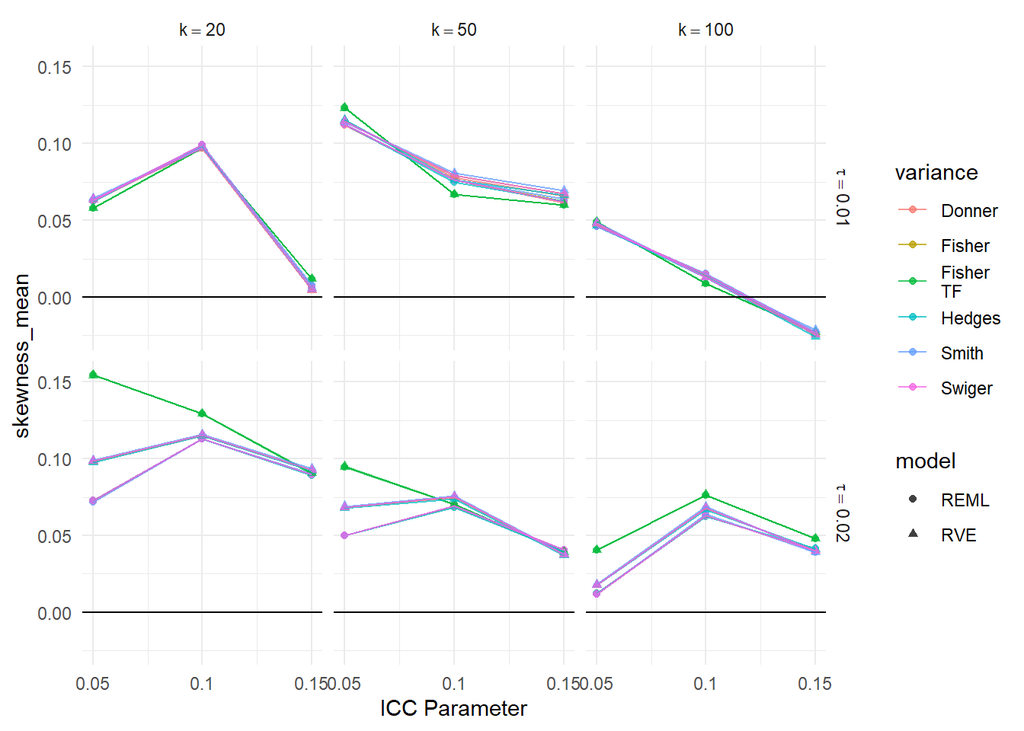

```r
perf_crit_agg <- perf_crit |>
  group_by(model, variance, icc_est_n , var_combo_graph, tau) |>
  summarise(skewness_mean = mean(skewness),
            kurtosis_mean = mean(kurtosis),
            n = n(),
            .groups = "drop")



ID1 <- c(0.05, 0.10, 0.15)

perf_crit_agg |>
  filter(var_combo_graph < 0.2) |>
  ggplot(aes(var_combo_graph, skewness_mean, col=variance, shape = model)) +
  facet_grid(tau ~ icc_est_n,
             labeller = label_bquote(rows = tau == .(tau),
                                            cols = k ==.(icc_est_n))) +
  geom_point( alpha=0.75 ) +
  geom_line( alpha=0.75 ) +
  geom_hline( yintercept = 0 ) +
  scale_x_continuous("ICC Parameter", labels = as.character(ID1), breaks = ID1) +
  theme_minimal()
```

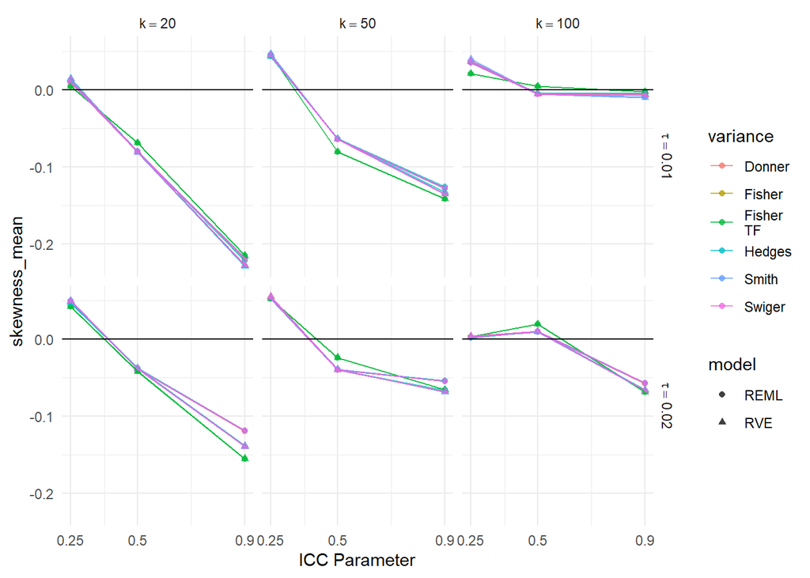

```r
ID2 <- c(0.25, 0.5, 0.9)

perf_crit_agg |>
  filter(var_combo_graph > 0.2) |>
  ggplot(aes(var_combo_graph, skewness_mean, col=variance, shape = model)) +
  facet_grid(tau ~ icc_est_n,
             labeller = label_bquote(rows = tau == .(tau),
                                            cols = k ==.(icc_est_n))) +
  geom_point( alpha=0.75 ) +
  geom_line( alpha=0.75 ) +
  geom_hline( yintercept = 0 ) +
  scale_x_continuous("ICC Parameter", labels = as.character(ID2), breaks = ID2) +
  theme_minimal()
```

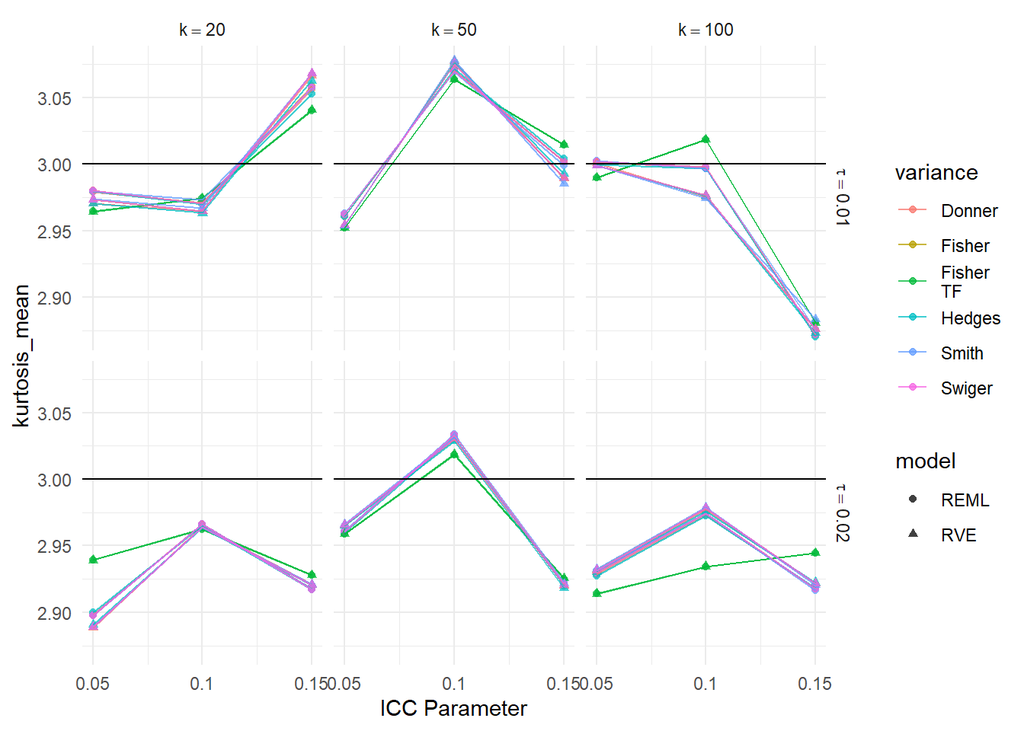

```r
ID1 <- c(0.05, 0.10, 0.15)

perf_crit_agg |>
  filter(var_combo_graph < 0.2) |>
  ggplot(aes(var_combo_graph, kurtosis_mean, col=variance, shape = model)) +
  facet_grid(tau ~ icc_est_n,
             labeller = label_bquote(rows = tau == .(tau),
                                            cols = k ==.(icc_est_n))) +
  geom_point( alpha=0.75 ) +
  geom_line( alpha=0.75 ) +
  geom_hline( yintercept = 3 ) +
  scale_x_continuous("ICC Parameter", labels = as.character(ID1), breaks = ID1) +
  theme_minimal()
```

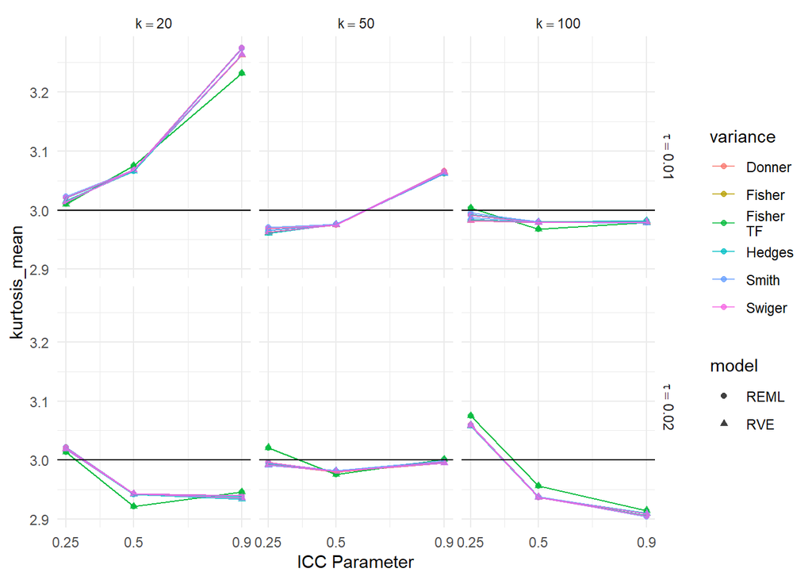

```r
ID2 <- c(0.25, 0.5, 0.9)

perf_crit_agg |>
  filter(var_combo_graph > 0.2) |>
  ggplot(aes(var_combo_graph, kurtosis_mean, col=variance, shape = model)) +
  facet_grid(tau ~ icc_est_n,
             labeller = label_bquote(rows = tau == .(tau),
                                            cols = k ==.(icc_est_n))) +
  geom_point( alpha=0.75 ) +
  geom_line( alpha=0.75 ) +
  geom_hline( yintercept = 3 ) +
  scale_x_continuous("ICC Parameter", labels = as.character(ID2), breaks = ID2) +
  theme_minimal()
```

```r
#Other Graphs

perf_crit |>
  ggplot(aes(x = factor(var_combo_graph), y = skewness, color = factor(icc_est_n))) +
  geom_point(alpha = .5, position = position_jitter(width = .3)) +
  geom_hline(yintercept = 0, linetype = "solid") +
  facet_grid(variance ~ model,
             labeller = label_bquote(rows = .(variance),
                                            cols = .(model))) +
  labs(x = "ICC Value", y = "Skewness", color = "k")

perf_crit |>
  ggplot(aes(x = factor(var_combo_graph), y = skewness, color = factor(tau))) +
  geom_point(alpha = .5, position = position_jitter(width = .3)) +
  geom_hline(yintercept = 0, linetype = "solid") +
  facet_grid(variance ~ icc_est_n,
             labeller = label_bquote(rows = .(variance),
                                            cols = k ==.(icc_est_n))) +
  labs(x = "ICC Value", y = "Skewness", color = "tau")


perf_crit |>
  ggplot(aes(x = factor(var_combo_graph), y = skewness, color = nj_graph)) +
  geom_point(alpha = .5, position = position_jitter(width = .3)) +
  geom_hline(yintercept = 0, linetype = "solid") +
  facet_grid(variance ~ icc_est_n,
             labeller = label_bquote(rows = .(variance),
                                            cols = k ==.(icc_est_n))) +
  labs(x = "ICC Value", y = "Skewness", color = "")

perf_crit |>
  ggplot(aes(x = factor(var_combo_graph), y = skewness, color = n_bar_graph)) +
  geom_point(alpha = .5, position = position_jitter(width = .3)) +
  geom_hline(yintercept = 0, linetype = "solid") +
  facet_grid(variance ~ icc_est_n,
             labeller = label_bquote(rows = .(variance),
                                            cols = k ==.(icc_est_n))) +
  labs(x = "ICC Value", y = "Skewness", color = "")


perf_crit |>
  ggplot(aes(x = factor(var_combo_graph), y = kurtosis, color = factor(icc_est_n))) +
  geom_point(alpha = .5, position = position_jitter(width = .3)) +
  geom_hline(yintercept = 3, linetype = "solid") +
  facet_grid(variance ~ model) +
  labs(x = "ICC Value", y = "Kurtosis", color = "k")


perf_crit |>
  ggplot(aes(x = factor(var_combo_graph), y = kurtosis, color = factor(tau))) +
  geom_point(alpha = .5, position = position_jitter(width = .3)) +
    geom_hline(yintercept = 3, linetype = "solid") +
  facet_grid(variance ~ icc_est_n,
             labeller = label_bquote(rows = .(variance),
                                            cols = k ==.(icc_est_n))) +
  labs(x = "ICC Value", y = "Kurtosis", color = "tau")


perf_crit |>
  ggplot(aes(x = factor(var_combo_graph), y = kurtosis, color = nj_graph)) +
  geom_point(alpha = .5, position = position_jitter(width = .3)) +
    geom_hline(yintercept = 3, linetype = "solid") +
  facet_grid(variance ~ icc_est_n,
             labeller = label_bquote(rows = .(variance),
                                            cols = k ==.(icc_est_n))) +
  labs(x = "ICC Value", y = "Kurtosis", color = "")

perf_crit |>
  ggplot(aes(x = factor(var_combo_graph), y = kurtosis, color = n_bar_graph)) +
  geom_point(alpha = .5, position = position_jitter(width = .3)) +
  geom_hline(yintercept = 3, linetype = "solid") +
  facet_grid(variance ~ icc_est_n,
             labeller = label_bquote(rows = .(variance),
                                            cols = k ==.(icc_est_n))) +
  labs(x = "ICC Value", y = "Kurtosis", color = "")
```

[output not shown]